# 19_germ_pseudotime_fine_nodes

Stephanie Hickey

2026-10-27

#### Lab: Weiming Li

#### Project: BCC125_sea_lamprey_scRNA

#### Lineage: all

```r
library(tidyverse)
library(SingleCellExperiment)
library(scater)
library(scran)
library(batchelor)
library(BiocSingular)
library(TSCAN)
library(patchwork)
library(DT)
library(ggraph)
library(tidygraph)
library(ggrepel)
source(paste0(params$project_dir, "/src/scRNA_seq_functions.R"))
```

TSCAN pseudotime for the all germ cells, with **every** cluster subclustered finely and no cell removed.

The tree TSCAN fits is a minimum spanning tree over one centroid per node, so the number of nodes is the number of points the trajectory is fitted to. `17` gives it around a dozen, of which four are whole clusters holding thousands of cells each. A tree on twelve points is coarse and moves whenever a node moves.

This document treats nodes as waypoints rather than cell types. Every cluster is cut into small subclusters at a fixed `sub_k`, which gives the tree many more points to follow. Nothing here needs a node to be interpretable, so nothing here depends on the subclustering being stable or on any node carrying a label.

The collaborators’ annotation is carried **per cell**, by barcode, from the run named in `prev_nodes_file`. It is never attached to a node. Re-clustering therefore cannot break it, and the interpretation is read off the composition of the trajectory rather than off node names.

```r
lineage = as.character(params$lineage)
if (!lineage %in% c("female", "male", "all"))
  stop("lineage must be 'female', 'male' or 'all', not '", lineage, "'")

clusters = trimws(strsplit(as.character(switch(lineage,
  female = params$female_clusters,
  male   = params$male_clusters,
  all    = params$all_clusters)), ",")[[1]])
clusters = clusters[nzchar(clusters)]

object_dir      = paste0(params$project_dir, "/results/", params$results_date,
                         "_no_doublets")
atlas_dir       = paste0(params$project_dir, "/results/", params$results_date,
                         "_atlas", params$atlas_suffix)
base_dir        = paste0(params$project_dir, "/results/", params$results_date,
                         "_pseudotime_fine_", lineage, params$atlas_suffix)
# run_suffix keeps the outputs of two settings side by side, for example a
# run with outgroup = TRUE against one without.
results_dir     = paste0(base_dir, params$run_suffix)
# the cache stays on the unsuffixed path: the corrected space does not depend
# on anything run_suffix varies, so it is built once and shared
Robject_out_dir = paste0(base_dir, "/Robjects")
if (!dir.exists(results_dir)) dir.create(results_dir, recursive = TRUE)
if (!dir.exists(Robject_out_dir)) dir.create(Robject_out_dir, recursive = TRUE)

label_file = paste0(atlas_dir, "/cell_cluster_labels.csv")
if (!file.exists(label_file))
  stop("missing ", label_file, ". Run 13 first.")

cell_labels      = read.csv(label_file, stringsAsFactors = FALSE)
all.sce          = readRDS(paste0(object_dir, "/all.sce.Rds"))
gene_description = read.csv(paste0(object_dir, "/gene_descritption.csv"),
                            stringsAsFactors = FALSE) %>%
  dplyr::distinct(Gene, .keep_all = TRUE)

lib_cols = c("Female" = "#FF6DB6", "Male" = "#006ddb",
             "Undifferentiated.1" = "#009292", "Undifferentiated.2" = "#b66ddf")
```

```r
# Read here rather than at the point of use, because the checks on the annotated
# run's nodes happen before the corrected space exists.
tech       = technical_gene_ids(gene_description)
mito_ids   = tech$mito
rrna_ids   = tech$rrna
ribo_ids   = tech$ribo
tech_genes = tech$all

# The pipeline computed subsets_Mito_percent before the cells were filtered on
# it, so that is the number the filtering was applied to and the one to report.
# Recomputing it here from the annotation would be a second, unvalidated
# definition of the same quantity.
mito_src = try(dplyr::bind_rows(lapply(all.sce, function(x) {
  cd = as.data.frame(colData(x))
  if (!"subsets_Mito_percent" %in% colnames(cd)) return(NULL)
  data.frame(barcode = colnames(x), pct_mito = cd$subsets_Mito_percent,
             stringsAsFactors = FALSE)
})), silent = TRUE)

have_mito_src = !inherits(mito_src, "try-error") && is.data.frame(mito_src) &&
                nrow(mito_src) > 0
```

15 mitochondrially encoded genes, 2 cytoplasmic rRNA genes and 162 ribosomal proteins are identified from the annotation. Percent mitochondrial is taken from subsets_Mito_percent in the per-library objects, which is the quantity the cells were filtered on upstream. Cytoplasmic 28S and 18S rRNA are counted separately, because they are not mitochondrial and are abundant enough to distort that fraction if folded into it.

```r
# Every set, not only the germ ones: a node scoring on a somatic set is the
# thing the fine cuts are most likely to turn up.
s1_sets = read.csv(paste0(params$project_dir, "/data/", params$marker_file),
                   stringsAsFactors = FALSE) %>%
  dplyr::mutate(loc_id = trimws(loc_id), origin = "S1 sheet")

# extra_marker_file takes a comma-separated list, so sets that did not come
# from the S1 sheet can be added independently of one another.
extra_file = trimws(strsplit(as.character(params$extra_marker_file), ",")[[1]])
extra_file = extra_file[nzchar(extra_file)]
extra_path = paste0(params$project_dir, "/data/", extra_file)
extra_ok   = file.exists(extra_path)
have_extra = any(extra_ok)
extra_missing = extra_file[!extra_ok]

all_sets = if (have_extra) {
  dplyr::bind_rows(s1_sets,
                   dplyr::bind_rows(lapply(extra_path[extra_ok], function(p)
                     read.csv(p, stringsAsFactors = FALSE) %>%
                       dplyr::mutate(loc_id = trimws(loc_id), origin = "extra"))))
} else s1_sets

# The sets that justify a removal are drawn on their own under Removal, so they
# are left out of the all-sets plot rather than drawn twice.
ev_sets = trimws(strsplit(as.character(params$removal_evidence_sets), ",")[[1]])
ev_sets = intersect(ev_sets[nzchar(ev_sets)], unique(all_sets$CellTypeMarkerSet))

set_origin = all_sets %>%
  dplyr::distinct(CellTypeMarkerSet, origin) %>%
  dplyr::group_by(CellTypeMarkerSet) %>%
  dplyr::summarise(origin = paste(sort(unique(origin)), collapse = ", "),
                   .groups = "drop")

# A set whose genes all sit inside another set is not a separate measurement.
# Scoring high on it says nothing about it that the larger set does not already
# say. The one-gene sets are where this bites.
set_genes = lapply(split(all_sets$loc_id, all_sets$CellTypeMarkerSet), unique)
set_containment = dplyr::bind_rows(lapply(names(set_genes), function(a)
  dplyr::bind_rows(lapply(setdiff(names(set_genes), a), function(b)
    if (length(set_genes[[a]]) > 0 && all(set_genes[[a]] %in% set_genes[[b]]))
      data.frame(set = a, contained_in = b, n_genes = length(set_genes[[a]]),
                 genes = paste(sort(set_genes[[a]]), collapse = ", "),
                 stringsAsFactors = FALSE)
    else NULL))))

# carried onto every set-score table, so a contained set is flagged where it is
# read rather than in a note further up the page
set_flag = if (nrow(set_containment) > 0) {
  set_containment %>%
    dplyr::group_by(set) %>%
    dplyr::summarise(contained_in = paste(sort(contained_in), collapse = ", "),
                     .groups = "drop")
} else data.frame(set = character(0), contained_in = character(0),
                  stringsAsFactors = FALSE)

# one row per marker gene per group, for the bubble plots. A gene belonging to
# two sets appears once per set, so the rows line up with sets_df positionally.
marker_bubble_df = function(lc, groups, sets_df) {
  present = sets_df %>%
    dplyr::distinct(CellTypeMarkerSet, loc_id, symbol) %>%
    dplyr::filter(loc_id %in% rownames(lc))
  groups  = as.character(groups)
  dplyr::bind_rows(lapply(unique(groups), function(gr) {
    m = as.matrix(lc[present$loc_id, groups == gr, drop = FALSE])
    data.frame(group          = gr,
               set            = present$CellTypeMarkerSet,
               gene           = present$loc_id,
               symbol         = present$symbol,
               n_cells        = sum(groups == gr),
               pct_expressing = 100 * rowMeans(m > 0),
               mean_logexpr   = rowMeans(m),
               stringsAsFactors = FALSE)
  }))
}

marker_bubble_plot = function(df, group_levels, title, subtitle = NULL) {
  df = df %>%
    dplyr::mutate(group = factor(group, levels = group_levels),
                  label = ifelse(is.na(symbol) | !nzchar(symbol), gene, symbol))
  ggplot(df, aes(x = group, y = label,
                 size = pct_expressing, colour = mean_logexpr)) +
    geom_point() +
    # inferno, as on the tree; viridis is pseudotime. Stopped short of the near
    # white top so the highest values stay visible.
    scale_colour_viridis_c(option = "inferno", end = .9) +
    scale_size_continuous(range = c(0.4, 5)) +
    facet_grid(set ~ ., scales = "free_y", space = "free_y") +
    theme_bw() +
    theme(strip.text.y     = element_text(angle = 0, size = 6),
          axis.text.y      = element_text(size = 6),
          axis.text.x      = element_text(size = 8, angle = 45, hjust = 1),
          panel.grid.major = element_line(linewidth = .2)) +
    labs(x = NULL, y = NULL, title = title, subtitle = subtitle,
         size = "% expressing", colour = "mean log expression")
}
```

```r
gaf_file      = file.path(params$genome_dir,
                          "GCF_010993605.1_kPetMar1.pri_gene_ontology.gaf")
go_names_file = file.path(params$genome_dir, "GOs_names.txt")
have_go       = file.exists(gaf_file) && file.exists(go_names_file)
```

```r
gaf = read.delim(gaf_file, header = FALSE, comment = "!") %>%
  dplyr::filter(!grepl("NOT", V4)) %>%
  dplyr::select(V3, V5) %>%
  dplyr::rename(GOID = "V5", Gene = "V3") %>%
  dplyr::distinct()

# terms too small are noise, terms too large are uninformative
keep_go = gaf %>%
  dplyr::count(GOID) %>%
  dplyr::filter(n > 10, n < 200) %>%
  dplyr::pull(GOID)
gaf = gaf %>% dplyr::filter(GOID %in% keep_go)

go_names = read.delim(go_names_file, header = FALSE)
colnames(go_names) = c("GOID", "GOName")
```

# Cells

```r
absent = setdiff(clusters, cell_labels$final_label)
if (length(absent) > 0)
  stop("cluster(s) ", paste(absent, collapse = ", "), " are not in ", label_file,
       ". Labels present: ",
       paste(sort(unique(cell_labels$final_label)), collapse = ", "))

lineage_key = cell_labels %>% dplyr::filter(final_label %in% clusters)

# the annotation, per cell, by barcode
parse_pairs = function(x) {
  x = trimws(x)
  if (!nzchar(x)) return(character(0))
  kv = strsplit(trimws(strsplit(x, ";")[[1]]), "=")
  setNames(vapply(kv, function(z) trimws(z[2]), character(1)),
           vapply(kv, function(z) trimws(z[1]), character(1)))
}

anno_map  = parse_pairs(params$node_annotation)
prev_file = as.character(params$prev_nodes_file)
have_prev = nzchar(prev_file) && file.exists(prev_file)

cell_anno = rep(NA_character_, nrow(lineage_key))
if (have_prev) {
  prev = read.csv(prev_file, stringsAsFactors = FALSE)
  stopifnot(all(c("barcode", "node") %in% colnames(prev)))
  old = prev$node[match(lineage_key$barcode, prev$barcode)]
  cell_anno = unname(anno_map[as.character(old)])
  cell_anno[is.na(cell_anno) & !is.na(old)] = as.character(old)[is.na(cell_anno) & !is.na(old)]
}
lineage_key$annotation = ifelse(is.na(cell_anno), "unannotated", cell_anno)


comp_tab = lineage_key %>%
  dplyr::count(final_label, annotation, name = "n") %>%
  tidyr::pivot_wider(names_from = annotation, values_from = n, values_fill = 0)

write.csv(comp_tab, file = paste0(results_dir, "/cluster_by_annotation.csv"),
          row.names = FALSE)

datatable(comp_tab, rownames = FALSE, options = list(dom = "t", scrollX = TRUE))
```

| final_label | Spermatogonia | Spermatocytes I | Spermatocytes II | Spermatocytes III | Granulosa | Migrating PGCs | Migrating female germ cells (FGC I) | Migrating female germ cells (FGC II) | Migrating neural crest cells | Oocytes | Oogonia | Primordial germ cells (PGCs) |
| --- | --- | --- | --- | --- | --- | --- | --- | --- | --- | --- | --- | --- |
| 15 | 918 | 0 | 0 | 0 | 0 | 0 | 0 | 0 | 0 | 0 | 0 | 0 |
| 16 | 0 | 5622 | 0 | 0 | 0 | 0 | 0 | 0 | 0 | 0 | 0 | 0 |
| 17 | 0 | 0 | 3950 | 0 | 0 | 0 | 0 | 0 | 0 | 0 | 0 | 0 |
| 18 | 0 | 0 | 0 | 4852 | 0 | 0 | 0 | 0 | 0 | 0 | 0 | 0 |
| 5 | 0 | 0 | 0 | 0 | 193 | 150 | 204 | 285 | 211 | 298 | 392 | 188 |

17,263 cells from cluster(s) 5, 15, 16, 17, 18. Nothing is removed here: the subclustering runs on every cell, and whatever is removed is removed afterwards, on the strength of what the nodes turn out to express. 17,263 carry an annotation from pseudotime_per_cell_annotated.csv.

```r
obj_file     = paste0(Robject_out_dir, "/lineage_objects.Rds")
obj_sig_file = paste0(Robject_out_dir, "/lineage_objects_signature.txt")
obj_sig      = paste(lineage, paste(sort(clusters), collapse = ","),
                     nrow(lineage_key), params$min_library_cells, sep = "|")

if (file.exists(obj_file) && file.exists(obj_sig_file) &&
    identical(readLines(obj_sig_file, warn = FALSE)[1], obj_sig)) {
  objs = readRDS(obj_file)
} else {
  objs = build_lineage_sce(all.sce, lineage_key$barcode,
                           min_library_cells = params$min_library_cells)
  saveRDS(objs, file = obj_file)
  writeLines(obj_sig, obj_sig_file)
}

merged   = objs$corrected
combined = objs$combined

key_idx = match(colnames(merged), lineage_key$barcode)
stopifnot(!anyNA(key_idx))
merged$library     = lineage_key$library[key_idx]
merged$stage       = lineage_key$stage[key_idx]
merged$final_label = lineage_key$final_label[key_idx]
merged$annotation  = lineage_key$annotation[key_idx]

lib_tab = data.frame(batch   = names(objs$n_by_library),
                     n_cells = as.integer(objs$n_by_library),
                     kept    = names(objs$n_by_library) %in% objs$kept_batches,
                     stringsAsFactors = FALSE) %>%
  dplyr::left_join(dplyr::distinct(cell_labels, batch, library), by = "batch")

datatable(lib_tab, rownames = FALSE, options = list(dom = "t"))
```

| batch | n_cells | kept | library |
| --- | --- | --- | --- |
| TF_C00004337 | 477 | True | Female |
| TM_C00004374 | 14344 | True | Male |
| UND1_C00004336 | 1260 | True | Undifferentiated.1 |
| UND2_C00004362 | 1182 | True | Undifferentiated.2 |

17,263 cells from 4 libraries are kept.

# Fine nodes

Every cluster is subclustered in the shared corrected space, using only that cluster’s cells, at a fixed `sub_k`. A smaller `sub_k` gives more and smaller subclusters. There is no stability sweep, because nothing downstream asks a node to be a reproducible cell type.

Subclusters below `min_node_cells` are merged into the nearest subcluster of the same parent cluster, by centroid distance. A node of five cells gives a centroid that is mostly noise, and the tree is fitted on centroids.

```r
set.seed(1)
sub_of = rep(NA_character_, ncol(merged))
names(sub_of) = colnames(merged)

for (cl in clusters) {
  cl_cells = colnames(merged)[merged$final_label == cl]
  if (length(cl_cells) < 2 * params$min_node_cells) {
    sub_of[cl_cells] = paste0(cl, ".1")
    next
  }
  set.seed(1)
  snn = buildSNNGraph(merged[, cl_cells], k = params$sub_k,
                      use.dimred = "corrected")
  mem = igraph::cluster_louvain(snn)$membership
  names(mem) = cl_cells

  # merge anything too small into the nearest surviving subcluster
  co = reducedDim(merged, "corrected")[cl_cells, , drop = FALSE]
  repeat {
    tab   = table(mem)
    small = names(tab)[tab < params$min_node_cells]
    if (length(small) == 0 || length(tab) <= 1) break
    cent = do.call(rbind, lapply(names(tab), function(g)
      colMeans(co[mem == g, , drop = FALSE])))
    rownames(cent) = names(tab)
    d = as.matrix(dist(cent))
    diag(d) = Inf
    s = small[which.min(tab[small])]
    mem[mem == s] = names(tab)[which.min(d[s, ])]
  }
  sub_of[cl_cells] = paste0(cl, ".", match(mem, sort(unique(mem))))
}

stopifnot(!anyNA(sub_of))

node_levels = unique(sub_of)
node_levels = node_levels[order(match(sub(
  "\\..*$", "", node_levels), clusters),
  as.integer(sub("^.*\\.", "", node_levels)))]
merged$node   = factor(sub_of, levels = node_levels)
combined$node = merged$node

node_tab = as.data.frame(colData(merged)) %>%
  dplyr::count(node, final_label, name = "n_cells") %>%
  dplyr::arrange(node)

write.csv(node_tab, file = paste0(results_dir, "/node_composition.csv"),
          row.names = FALSE)

datatable(node_tab, rownames = FALSE, options = list(pageLength = 15))
```

| node | final_label | n_cells |
| --- | --- | --- |
| 5.1 | 5 | 206 |
| 5.2 | 5 | 158 |
| 5.3 | 5 | 151 |
| 5.4 | 5 | 241 |
| 5.5 | 5 | 247 |
| 5.6 | 5 | 240 |
| 5.7 | 5 | 123 |
| 5.8 | 5 | 338 |
| 5.9 | 5 | 67 |
| 5.10 | 5 | 150 |

[output cut: 29 more lines]

39 nodes from 5 clusters, at sub_k = 10, with a floor of 30 cells. Median node size 341 cells, smallest 67, largest 1437.

```r
per_cluster = node_tab %>%
  dplyr::count(final_label, name = "n_nodes") %>%
  dplyr::arrange(match(final_label, clusters))
datatable(per_cluster, rownames = FALSE, options = list(dom = "t", paging = FALSE))
```

| final_label | n_nodes |
| --- | --- |
| 5 | 10 |
| 15 | 6 |
| 16 | 8 |
| 17 | 6 |
| 18 | 9 |

## What the nodes are made of

Nodes are not cell types, so the question is not what each one is but how the annotation is distributed over them. A node drawn from one annotation is a waypoint inside that population. A node mixing several is a waypoint on a boundary, which is expected wherever the biology is continuous.

```r
anno_by_node = as.data.frame(colData(merged)) %>%
  dplyr::count(node, annotation, name = "n") %>%
  dplyr::group_by(node) %>%
  dplyr::mutate(frac = n / sum(n)) %>%
  dplyr::ungroup()

write.csv(anno_by_node, file = paste0(results_dir, "/node_by_annotation.csv"),
          row.names = FALSE)

p_anno = ggplot(anno_by_node, aes(x = node, y = frac, fill = annotation)) +
  geom_col() +
  theme_bw() +
  theme(axis.text.x = element_text(angle = 90, hjust = 1, vjust = .5, size = 7),
        legend.text = element_text(size = 7)) +
  labs(x = NULL, y = "fraction of the node", fill = NULL,
       title = "Annotation composition of each node")

p_anno
```

[figure not shown]

```r
ggsave(p_anno, file = paste0(results_dir, "/node_by_annotation.png"),
       width = 12, height = 5, dpi = 300)
```

## Depth and technical content

Nodes that differ by sequencing depth rather than by cell state show a characteristic pattern. The shallower node’s markers are the abundant genes of the deeper one at lower magnitude, and housekeeping genes climb its marker list. Cutting every cluster finely makes this more likely, not less, so it is measured directly here.

```r
cnt = counts(combined)
tot = Matrix::colSums(cnt)

# built once, with everything the later sections need: the node for this
# section, the library and pseudotime for What else the ordering tracks
qc = data.frame(
  barcode   = colnames(combined),
  node      = as.character(merged$node),
  library   = as.character(merged$library),
  total     = as.numeric(tot),
  detected  = as.numeric(Matrix::colSums(cnt > 0)),
  pct_rrna  = 100 * as.numeric(Matrix::colSums(
                cnt[intersect(rrna_ids, rownames(cnt)), , drop = FALSE])) / tot,
  pct_ribo  = 100 * as.numeric(Matrix::colSums(
                cnt[intersect(ribo_ids, rownames(cnt)), , drop = FALSE])) / tot,
  stringsAsFactors = FALSE)

qc = if (have_mito_src) {
  qc %>% dplyr::left_join(mito_src, by = "barcode")
} else qc %>% dplyr::mutate(
  pct_mito = 100 * as.numeric(Matrix::colSums(
               cnt[intersect(mito_ids, rownames(cnt)), , drop = FALSE])) / tot)

qc_tab = qc %>%
  dplyr::group_by(node) %>%
  dplyr::summarise(n_cells = dplyr::n(),
                   median_total    = round(median(total)),
                   median_detected = round(median(detected)),
                   median_pct_mito = round(median(pct_mito), 1),
                   median_pct_rrna = round(median(pct_rrna), 1),
                   median_pct_ribo = round(median(pct_ribo), 1),
                   .groups = "drop") %>%
  dplyr::mutate(node = factor(node, levels = node_levels)) %>%
  dplyr::arrange(node)

write.csv(qc_tab, file = paste0(results_dir, "/node_depth_and_technical.csv"),
          row.names = FALSE)

datatable(qc_tab, rownames = FALSE, filter = "top",
          options = list(pageLength = 15, scrollX = TRUE))
```

| node | n_cells | median_total | median_detected | median_pct_mito | median_pct_rrna | median_pct_ribo |
| --- | --- | --- | --- | --- | --- | --- |
| 5.1 | 206 | 5980 | 1548 | 1.3 | 0.1 | 23.8 |
| 5.2 | 158 | 55832 | 5632 | 0.9 | 1.5 | 21.6 |
| 5.3 | 151 | 20087 | 3411 | 0 | 0.2 | 7.6 |
| 5.4 | 241 | 27727 | 3917 | 0 | 0.1 | 6.5 |
| 5.5 | 247 | 108044 | 7310 | 0.4 | 1 | 17.2 |
| 5.6 | 240 | 135010 | 8058 | 0.3 | 0.8 | 15.5 |
| 5.7 | 123 | 11150 | 3382 | 0.9 | 0.6 | 12.3 |
| 5.8 | 338 | 3504 | 1148 | 0.5 | 0.1 | 18.3 |
| 5.9 | 67 | 3489 | 1368 | 0.1 | 11.3 | 2.8 |
| 5.10 | 150 | 102042 | 7259 | 0.6 | 1.2 | 19.3 |

[output cut: 29 more lines]

```r
qc_long = qc %>%
  dplyr::mutate(node = factor(node, levels = node_levels)) %>%
  tidyr::pivot_longer(c(total, detected, pct_mito, pct_rrna, pct_ribo),
                      names_to = "measure", values_to = "value") %>%
  dplyr::mutate(measure = factor(measure,
                  levels = c("total", "detected", "pct_mito", "pct_rrna",
                             "pct_ribo"),
                  labels = c("total counts", "genes detected",
                             "percent mitochondrial", "percent 28S/18S rRNA",
                             "percent ribosomal protein")))

p_qc = ggplot(qc_long, aes(x = node, y = value)) +
  geom_violin(scale = "width", fill = "grey90", colour = NA) +
  geom_boxplot(width = .18, outlier.size = .2) +
  facet_wrap(~ measure, scales = "free_y", ncol = 2) +
  scale_y_continuous(trans = "log1p") +
  theme_bw() +
  theme(axis.text.x = element_text(angle = 45, hjust = 1, size = 5)) +
  labs(x = NULL, y = NULL, title = "Depth and technical content by node",
       subtitle = "log1p scale")

p_qc
```

[figure not shown]

```r
ggsave(p_qc, file = paste0(results_dir, "/node_depth_and_technical.png"),
       width = 11, height = 11, dpi = 300)
```

```r
# Does node membership track depth within a cluster? Every cluster is cut here,
# so the test runs on all of them: Kruskal-Wallis across the subclusters of one
# cluster, plus how far apart the extreme nodes sit in median depth.
depth_tests = dplyr::bind_rows(lapply(clusters, function(cl) {
  sub = qc %>% dplyr::filter(grepl(paste0("^", cl, "\\."), node))
  if (dplyr::n_distinct(sub$node) < 2) return(NULL)
  med = sub %>% dplyr::group_by(node) %>%
    dplyr::summarise(m = median(total), .groups = "drop")
  dplyr::bind_rows(lapply(c("total", "detected", "pct_mito", "pct_rrna",
                            "pct_ribo"), function(v) {
    kt = kruskal.test(sub[[v]] ~ factor(sub$node))
    data.frame(cluster = cl, measure = v,
               kruskal_p  = signif(kt$p.value, 3),
               fold_range = signif(max(med$m) / min(med$m), 3),
               stringsAsFactors = FALSE)
  }))
}))

if (!is.null(depth_tests) && nrow(depth_tests) > 0) {
  depth_tests$fold_range[depth_tests$measure != "total"] = NA
  write.csv(depth_tests, file = paste0(results_dir, "/node_depth_tests.csv"),
            row.names = FALSE)
  datatable(depth_tests, rownames = FALSE,
            options = list(pageLength = 15, scrollX = TRUE))
}
```

| cluster | measure | kruskal_p | fold_range |
| --- | --- | --- | --- |
| 5 | total | 2.779999999999999e-205 | 38.7 |
| 5 | detected | 7.609999999999996e-205 |  |
| 5 | pct_mito | 8.049999999999997e-243 |  |
| 5 | pct_rrna | 2.479999999999999e-160 |  |
| 5 | pct_ribo | 9.269999999999994e-291 |  |
| 15 | total | 4.83e-06 | 1.24 |
| 15 | detected | 2.46e-08 |  |
| 15 | pct_mito | 0.00488 |  |
| 15 | pct_rrna | 1.769999999999999e-99 |  |
| 15 | pct_ribo | 9.36e-30 |  |

[output cut: 15 more lines]

Median total counts across the subclusters of cluster 5, 15, 16, 17, 18 differ by a factor of 38.7, 1.24, 1.88, 1.14, 1.63 between the deepest and shallowest node (Kruskal-Wallis p 2.78e-205, 4.83e-06, 5.27e-153, 1.38e-32, 5.18e-49). A large factor is the signature of a depth split. It does not prove one, because a real cell state can also carry more RNA.

## Node identity

Every node is scored against **all** the marker sets available, somatic ones included, rather than only the germ sets the root rule uses. Every cell is still here: nothing has been removed at this point, and this table is what any removal below is decided on. A node scoring high on a somatic set and low on every germ set is not a germ cell state.

The sets named by `removal_evidence_sets` are left out of the figure and drawn on their own under Removal. They are still in the table and in `node_identity_scores.csv`.

```r
if (nrow(set_containment) > 0)
  datatable(set_containment, rownames = FALSE,
            options = list(dom = "t", paging = FALSE))
```

| set | contained_in | n_genes | genes |
| --- | --- | --- | --- |
| Spermatogonial stem cells | Neural crest | 1 | PAX7 |

**1 marker set(s) sit entirely inside another set.** A node scoring high on one of these is also scoring high on the set that contains it. The two cannot be read as separate evidence. Judge these from the per-gene plot rather than the set score.

```r
id_genes = all_sets %>%
  dplyr::transmute(set = CellTypeMarkerSet, gene = loc_id) %>%
  dplyr::filter(gene %in% rownames(combined)) %>%
  dplyr::distinct()

id_scores = score_marker_sets(combined, merged$node, id_genes) %>%
  dplyr::rename(node = group)

id_table = id_scores %>%
  dplyr::left_join(set_origin, by = c("set" = "CellTypeMarkerSet")) %>%
  dplyr::left_join(set_flag, by = "set") %>%
  dplyr::mutate(node = factor(node, levels = node_levels),
                contained_in = tidyr::replace_na(contained_in, ""),
                mean_logexpr = signif(mean_logexpr, 3),
                pct_detected = round(pct_detected, 1)) %>%
  dplyr::arrange(node, dplyr::desc(mean_logexpr)) %>%
  dplyr::select(node, set, origin, contained_in, n_genes, n_cells,
                mean_logexpr, pct_detected)

write.csv(id_table, file = paste0(results_dir, "/node_identity_scores.csv"),
          row.names = FALSE)

# one row per gene per set, so the height follows the gene count. Fixed, the
# facets compress as sets are added.
id_rows = nrow(dplyr::distinct(
  all_sets %>% dplyr::filter(!CellTypeMarkerSet %in% ev_sets),
  CellTypeMarkerSet, loc_id))
id_h    = max(9, round(0.17 * id_rows + 3))

datatable(id_table, rownames = FALSE, filter = "top",
          options = list(pageLength = 20, scrollX = TRUE))
```

| node | set | origin | contained_in | n_genes | n_cells | mean_logexpr | pct_detected |
| --- | --- | --- | --- | --- | --- | --- | --- |
| 5.1 | Dissociation response | extra |  | 25 | 206 | 0.588 | 19.5 |
| 5.1 | Erythrocytes | S1 sheet |  | 4 | 206 | 0.558 | 19.9 |
| 5.1 | Oocyte | S1 sheet |  | 6 | 206 | 0.471 | 20.7 |
| 5.1 | Migrating germ cells | S1 sheet |  | 2 | 206 | 0.466 | 26.7 |
| 5.1 | Mesonephric cells | S1 sheet |  | 7 | 206 | 0.131 | 9.3 |
| 5.1 | Spermatogonial stem cells | S1 sheet | Neural crest | 1 | 206 | 0.0807 | 6.3 |
| 5.1 | Mesenephric podocytes | S1 sheet |  | 2 | 206 | 0.0773 | 7.5 |
| 5.1 | Primordial germ cells | S1 sheet |  | 4 | 206 | 0.073 | 6.2 |
| 5.1 | Pre-granulosa cells | S1 sheet |  | 3 | 206 | 0.0602 | 5.3 |
| 5.1 | Granulosa cells | S1 sheet |  | 5 | 206 | 0.0508 | 4.6 |

[output cut: 614 more lines]

```r
id_bubble = marker_bubble_df(logcounts(combined), merged$node, all_sets)
write.csv(id_bubble, file = paste0(results_dir, "/node_marker_expression.csv"),
          row.names = FALSE)

p_identity = marker_bubble_plot(
  id_bubble %>% dplyr::filter(!set %in% ev_sets), node_levels,
  title = "Marker expression by node, every set")

p_identity
```

[figure not shown]

```r
ggsave(p_identity, file = paste0(results_dir, "/node_identity_scores.png"),
       width = 11, height = id_h, dpi = 300)
```

# Removal

Every node above was defined on every cell, with nothing taken out, and scored against every marker set. A node is removed here only on the strength of what it turned out to express. Removing on the strength of the label it was given would make the trajectory unable to say anything about that label.

`removal_evidence_sets` names the sets drawn below. Dissociation response holds the AP-1 and immediate-early genes that enzymatic digestion induces, so a node carrying them is defined by how the tissue was handled rather than by the animal. `drop_nodes` names the nodes to remove, by node, after reading it.

```r
drop_nodes = trimws(strsplit(as.character(params$drop_nodes), ",")[[1]])
drop_nodes = drop_nodes[nzchar(drop_nodes)]
absent = setdiff(drop_nodes, node_levels)
if (length(absent) > 0)
  stop("drop_nodes names node(s) that do not exist: ", paste(absent, collapse = ", "),
       ". Nodes: ", paste(node_levels, collapse = ", "))

# the nodes being removed first on the axis, so the comparison is immediate
ev_levels = c(drop_nodes, setdiff(node_levels, drop_nodes))

ev_rows = nrow(dplyr::distinct(
  all_sets %>% dplyr::filter(CellTypeMarkerSet %in% ev_sets),
  CellTypeMarkerSet, loc_id))
ev_h = max(5, round(0.19 * ev_rows + 2))
```

```r
if (length(ev_sets) > 0) {
  p_ev = marker_bubble_plot(
    id_bubble %>% dplyr::filter(set %in% ev_sets), ev_levels,
    title    = paste(ev_sets, collapse = ", "),
    subtitle = if (length(drop_nodes) == 0) "nothing is being removed" else
      paste0("removed: ", paste(drop_nodes, collapse = ", ")))
  print(p_ev)
  ggsave(p_ev, file = paste0(results_dir, "/removal_evidence_bubble.png"),
         width = 9, height = ev_h, dpi = 300)
}
```

[figure not shown]

The highest scoring node on Dissociation response is 5.1 at 0.588, detected in 19.5 percent of its cells, against 0.361 for the next node. The per-node values are in node_identity_scores.csv.

```r
drop_tab = NULL
if (length(drop_nodes) > 0) {
  drop_tab = data.frame(node = drop_nodes, stringsAsFactors = FALSE) %>%
    dplyr::left_join(as.data.frame(table(node = as.character(merged$node)),
                                   stringsAsFactors = FALSE) %>%
                       dplyr::rename(cells = Freq), by = "node")

  # The space and the node definitions are kept as they are. Rebuilding them
  # without these cells would change every node, which is the thing this
  # ordering was meant to avoid.
  keep = !(as.character(merged$node) %in% drop_nodes)
  merged   = merged[, keep]
  combined = combined[, keep]
  merged$node = droplevels(factor(as.character(merged$node),
                                  levels = node_levels))
  node_levels = levels(merged$node)
  qc = qc %>% dplyr::filter(barcode %in% colnames(merged))

  datatable(drop_tab, rownames = FALSE, options = list(dom = "t", paging = FALSE))
}
```

| node | cells |
| --- | --- |
| 5.1 | 206 |

206 cells in 1 node(s) are removed. 38 nodes and 17,057 cells go forward. The space and the node boundaries are the ones fitted above, so the nodes that remain are unchanged by the removal.

# Root

Every node is scored on the germ cell marker sets. The root is the node with the highest mean expression of the set named in `root_rule`, unless `root_node` names one directly. This does not consult the annotation, so the root does not depend on any label being right.

```r
germ_sets = c("Primordial germ cells", "Migrating germ cells",
              "Spermatogonial stem cells", "Spermatocytes", "Oocyte")

set_genes = read.csv(paste0(params$project_dir, "/data/", params$marker_file),
                     stringsAsFactors = FALSE) %>%
  dplyr::mutate(loc_id = trimws(loc_id)) %>%
  dplyr::filter(CellTypeMarkerSet %in% germ_sets) %>%
  dplyr::transmute(set = CellTypeMarkerSet, gene = loc_id)

set_scores = score_marker_sets(combined, merged$node, set_genes) %>%
  dplyr::rename(node = group)

# one row per node, two columns per set, which reads better than the long form
set_table = set_scores %>%
  dplyr::mutate(set          = factor(set, levels = germ_sets),
                node         = factor(node, levels = node_levels),
                mean_logexpr = signif(mean_logexpr, 3),
                pct_detected = round(pct_detected, 1)) %>%
  dplyr::arrange(set, node) %>%
  tidyr::pivot_wider(id_cols = c(node, n_cells), names_from = set,
                     values_from = c(mean_logexpr, pct_detected),
                     names_glue = "{set}: {.value}") %>%
  dplyr::arrange(node)

write.csv(set_table, file = paste0(results_dir, "/node_marker_set_scores.csv"),
          row.names = FALSE)

datatable(set_table, rownames = FALSE, filter = "top",
          options = list(pageLength = 15, scrollX = TRUE))
```

| node | n_cells | Primordial germ cells: mean_logexpr | Migrating germ cells: mean_logexpr | Spermatogonial stem cells: mean_logexpr | Spermatocytes: mean_logexpr | Oocyte: mean_logexpr | Primordial germ cells: pct_detected | Migrating germ cells: pct_detected | Spermatogonial stem cells: pct_detected | Spermatocytes: pct_detected | Oocyte: pct_detected |
| --- | --- | --- | --- | --- | --- | --- | --- | --- | --- | --- | --- |
| 5.2 | 158 | 0.143 | 0.42 | 0.0683 | 0.229 | 0.289 | 39.2 | 64.6 | 31.6 | 42 | 39.6 |
| 5.3 | 151 | 0.093 | 0.978 | 0.0925 | 0.0212 | 2.66 | 17.4 | 73.5 | 16.6 | 4.8 | 67.5 |
| 5.4 | 241 | 0.0835 | 0.95 | 0.0887 | 0.016 | 2.76 | 19.8 | 72 | 23.7 | 4.5 | 68.5 |
| 5.5 | 247 | 0.144 | 0.425 | 0.0851 | 0.199 | 0.482 | 48.9 | 71.9 | 42.5 | 44.3 | 56.3 |
| 5.6 | 240 | 0.139 | 0.449 | 0.0803 | 0.152 | 0.877 | 56.4 | 81.7 | 48.3 | 46 | 71.7 |
| 5.7 | 123 | 0.165 | 0.789 | 0.101 | 0.194 | 0.412 | 24.8 | 56.5 | 21.1 | 22.8 | 34 |
| 5.8 | 338 | 0.0853 | 0.306 | 0.0705 | 0.0966 | 0.366 | 8.1 | 21.7 | 7.1 | 8.2 | 18.1 |
| 5.9 | 67 | 0.112 | 0.274 | 0.0518 | 0.132 | 0.184 | 5.2 | 16.4 | 3 | 7.2 | 10.7 |
| 5.10 | 150 | 0.158 | 0.405 | 0.0797 | 0.222 | 0.499 | 55 | 81 | 40.7 | 51.5 | 58.9 |
| 15.1 | 209 | 0.0904 | 1.2 | 0.0577 | 0.528 | 0.0471 | 9.4 | 51.7 | 7.7 | 34.3 | 4.9 |

[output cut: 28 more lines]

```r
root_req = as.character(params$root_node)
if (nzchar(root_req)) {
  if (!root_req %in% node_levels)
    stop("root_node '", root_req, "' is not a node. Nodes: ",
         paste(node_levels, collapse = ", "))
  root      = root_req
  rule_set  = NA_character_
  root_pct  = NA_real_
  weak_root = FALSE
} else {
  rp = regmatches(params$root_rule,
                  regexec("^(max|min):(.+)$", params$root_rule))[[1]]
  if (length(rp) != 3)
    stop("root_rule '", params$root_rule, "' must look like max:<set> or min:<set>")
  rule_dir = rp[2]
  rule_set = trimws(rp[3])
  if (!rule_set %in% germ_sets)
    stop("root rule set '", rule_set, "' is not one of: ",
         paste(germ_sets, collapse = ", "))

  cand = set_scores %>% dplyr::filter(set == rule_set, !is.na(mean_logexpr))
  if (nrow(cand) == 0)
    stop("no gene from the ", rule_set, " set is in the data; set root_node")
  pick      = if (rule_dir == "max") which.max(cand$mean_logexpr) else
                which.min(cand$mean_logexpr)
  root      = as.character(cand$node[pick])
  root_pct  = cand$pct_detected[pick]
  weak_root = rule_dir == "max" && root_pct < params$min_detect_pct
}
```

Rooted at **5.7**, the node with the highest mean expression of the Primordial germ cells set, detected in 24.8 percent of its cells. The root is an assumption. Rooting elsewhere gives a different ordering.

# Node markers

Markers for each trajectory node from `findMarkers` on uncorrected log counts, comparing each node with every other node in this lineage (`direction = "up"`, `pval.type = "some"`). Library is not blocked: a node drawn mostly from one library has no within-library comparison, so its markers include library differences. Genes are kept at FDR < 0.01 with a mean log fold change of at least 1, and written to `node_marker_genes.csv`.

Cutting every cluster finely leaves each node few cells and many neighbors that resemble it, so fewer genes survive here than in `17`.

```r
# mean over every pairwise logFC; summary.logFC under pval.type = "some" comes
# from whichever comparison supplied the p-value, so it is not a fixed contrast
marker_effect = function(df) {
  lf = grep("^logFC\\.", colnames(df), value = TRUE)
  if (length(lf) == 0) return(rep(NA_real_, nrow(df)))
  rowMeans(as.matrix(as.data.frame(df[, lf, drop = FALSE])), na.rm = TRUE)
}

mk_file         = paste0(Robject_out_dir, "/node_markers.Rds")
mk_sig_file     = paste0(Robject_out_dir, "/node_markers_signature.txt")
marker_sig      = paste(obj_sig, paste(node_levels, collapse = ","),
                        paste(as.integer(table(merged$node)), collapse = ","),
                        sep = "|")

if (file.exists(mk_file) && file.exists(mk_sig_file) &&
    identical(readLines(mk_sig_file, warn = FALSE)[1], marker_sig)) {
  sub_markers = readRDS(mk_file)
} else {
  sub_markers = findMarkers(combined, combined$node, test.type = "t",
                            direction = "up", pval.type = "some")
  saveRDS(sub_markers, file = mk_file)
  writeLines(marker_sig, mk_sig_file)
}

sub_marker_tab = purrr::map_dfr(names(sub_markers), function(nd) {
  df = sub_markers[[nd]]
  data.frame(node      = nd,
             Gene      = rownames(df),
             p.value   = df$p.value,
             FDR       = df$FDR,
             meanLogFC = marker_effect(df),
             stringsAsFactors = FALSE)
}) %>%
  dplyr::filter(FDR < 0.01, meanLogFC >= params$lfc_thresh) %>%
  dplyr::left_join(gene_description, by = "Gene") %>%
  dplyr::group_by(node) %>%
  dplyr::arrange(desc(meanLogFC), FDR, .by_group = TRUE) %>%
  dplyr::ungroup() %>%
  dplyr::select(node, Gene, WangGeneID, description, meanLogFC, p.value, FDR)

write.csv(sub_marker_tab, file = paste0(results_dir, "/node_marker_genes.csv"),
          row.names = FALSE)

marker_counts = data.frame(node = node_levels) %>%
  dplyr::left_join(sub_marker_tab %>% dplyr::count(node, name = "n_markers"),
                   by = "node") %>%
  dplyr::mutate(n_markers = ifelse(is.na(n_markers), 0L, n_markers))

datatable(marker_counts, rownames = FALSE,
          options = list(pageLength = 15, scrollX = TRUE))
```

| node | n_markers |
| --- | --- |
| 5.2 | 133 |
| 5.3 | 240 |
| 5.4 | 231 |
| 5.5 | 150 |
| 5.6 | 165 |
| 5.7 | 164 |
| 5.8 | 83 |
| 5.9 | 32 |
| 5.10 | 207 |
| 15.1 | 30 |

[output cut: 28 more lines]

```r
datatable(sub_marker_tab %>%
            dplyr::mutate(dplyr::across(c(meanLogFC, p.value, FDR),
                                        ~signif(., 3))),
          filter = "top", rownames = FALSE,
          options = list(pageLength = 15, scrollX = TRUE))
```

| node | Gene | WangGeneID | description | meanLogFC | p.value | FDR |
| --- | --- | --- | --- | --- | --- | --- |
| 15.1 | LOC116947507 | LOC116947507 | tubulin alpha chain, testis-specific-like | 2.47 | 7.779999999999997e-127 | 4.27e-123 |
| 15.1 | LOC116951539 | BIRC5 | baculoviral IAP repeat-containing protein 5-like | 2.1 | 5.349999999999999e-95 | 2.35e-91 |
| 15.1 | LOC116955455 | TUBB4A | tubulin beta-4 chain-like | 2.08 | 8.069999999999998e-85 | 2.22e-81 |
| 15.1 | CCNB2 | CCNB2 | cyclin B2 | 2.07 | 3.219999999999999e-89 | 1.18e-85 |
| 15.1 | LOC116952975 | HMGN2 | non-histone chromosomal protein HMG-17-like, transcript variant X1 | 2.05 | 1.879999999999999e-164 | 4.129999999999999e-160 |
| 15.1 | LOC116937082 | LOC116937082 | inference COORDINATES: nucleotide motif:Rfam:12.0:RF02543 | 1.9 | 1.67e-26 | 8.35e-24 |
| 15.1 | LOC116937088 | LOC116937088 | inference COORDINATES: nucleotide motif:Rfam:12.0:RF02543 | 1.89 | 1.88e-24 | 7.53e-22 |
| 15.1 | LOC116937092 | LOC116937092 | 28S ribosomal RNA | 1.83 | 4.53e-26 | 2.16e-23 |
| 15.1 | LOC116955023 | CKS1 | cyclin-dependent kinases regulatory subunit 1, transcript variant X1 | 1.79 | 1.58e-84 | 3.86e-81 |
| 15.1 | NUF2 | NUF2 | NUF2 component of NDC80 kinetochore complex, transcript variant X1 | 1.74 | 2.559999999999999e-88 | 8.019999999999999e-85 |

[output cut: 1802 more lines]

## GO enrichment of node markers

GO enrichment of each node’s marker genes, against every gene in the data. Terms with p < 0.05 are shown and written to `node_marker_GO_pvalues.csv`.

```r
marker_go = run_go_enrichment(
  gaf              = gaf,
  gene_description = gene_description,
  go_names         = go_names,
  test_genes       = sub_marker_tab %>% dplyr::select(Gene, node) %>%
                       dplyr::distinct(),
  background_n     = nrow(combined),
  group2_label     = "node",
  ngroup2_label    = "nMarkerGenes",
  overlaps_file    = paste0(results_dir, "/node_marker_GO_overlaps.csv"),
  pvals_file       = paste0(results_dir, "/node_marker_GO_pvalues.csv"),
  pval_filter      = params$go_pval)

datatable(marker_go %>% dplyr::mutate(dplyr::across(where(is.numeric),
                                                    ~signif(., 3))),
          filter = "top", rownames = FALSE)
```

| GOID | GOName | nGOTermGenes | node | nMarkerGenes | nSharedGenes | Pval | FDR |
| --- | --- | --- | --- | --- | --- | --- | --- |
| GO:0000027 | ribosomal large subunit assembly | 16 | 16.7 | 35 | 1 | 0.0252 | 0.972 |
| GO:0000027 | ribosomal large subunit assembly | 16 | 5.7 | 164 | 2 | 0.00621 | 0.277 |
| GO:0000079 | regulation of cyclin-dependent protein serine/threonine kinase activity | 25 | 15.1 | 30 | 2 | 0.00053 | 0.0409 |
| GO:0000079 | regulation of cyclin-dependent protein serine/threonine kinase activity | 25 | 15.2 | 34 | 2 | 0.000682 | 0.0483 |
| GO:0000079 | regulation of cyclin-dependent protein serine/threonine kinase activity | 25 | 15.3 | 30 | 2 | 0.00053 | 0.0409 |
| GO:0000079 | regulation of cyclin-dependent protein serine/threonine kinase activity | 25 | 15.4 | 38 | 2 | 0.000852 | 0.0905 |
| GO:0000079 | regulation of cyclin-dependent protein serine/threonine kinase activity | 25 | 15.5 | 42 | 1 | 0.0467 | 1 |
| GO:0000079 | regulation of cyclin-dependent protein serine/threonine kinase activity | 25 | 15.6 | 41 | 2 | 0.000992 | 0.0648 |
| GO:0000079 | regulation of cyclin-dependent protein serine/threonine kinase activity | 25 | 5.3 | 240 | 3 | 0.00248 | 0.117 |
| GO:0000079 | regulation of cyclin-dependent protein serine/threonine kinase activity | 25 | 5.4 | 231 | 4 | 0.000127 | 0.00717 |

[output cut: 239 more lines]

# Trajectory

`dist_method` sets how the distance between two nodes is measured. `simple` is plain Euclidean distance between centroids and is the TSCAN default. `mnn`, the default here, instead finds the mutual nearest neighbor pairs between each pair of nodes and takes the median distance between them. It therefore measures how close two nodes are at their *boundaries* rather than at their centers, which is the right question when nodes are broad and intermingle. `mnn_k` sets how many neighbors the search considers.

MNN runs a cell-based neighbor search for every pair of nodes, so it costs more time and memory than `simple`, and that cost grows with the number of nodes.

`outgroup` decides whether every node must join one tree. With `FALSE` the tree is forced to be connected, so a node that belongs nowhere is still grafted on at its nearest neighbor. With `TRUE`, an edge longer than 1.5 times the median edge length is rerouted through an artificial outgroup and the tree breaks into components. That is how a node detaches itself rather than being removed by hand.

```r
pseudo_file     = paste0(Robject_out_dir, "/tscan_pseudo.Rds")
pseudo_sig_file = paste0(Robject_out_dir, "/tscan_pseudo_signature.txt")
pseudo_sig      = paste(obj_sig, root, params$sub_k, params$min_node_cells,
                        params$dist_method, params$mnn_k, params$outgroup,
                        paste(node_levels, collapse = ","), sep = "|")

if (file.exists(pseudo_file) && file.exists(pseudo_sig_file) &&
    identical(readLines(pseudo_sig_file, warn = FALSE)[1], pseudo_sig)) {
  pseudo = readRDS(pseudo_file)
} else {
  set.seed(1)
  pseudo = quickPseudotime(merged,
                           clusters    = merged$node,
                           use.dimred  = "corrected",
                           dist.method = as.character(params$dist_method),
                           mnn.k       = params$mnn_k,
                           outgroup    = params$outgroup,
                           start       = root)
  saveRDS(pseudo, file = pseudo_file)
  writeLines(pseudo_sig, pseudo_sig_file)
}

# One column per path, kept so the gene test and the heatmaps can work path by
# path. The average over a cell's paths is a single number per cell, which the
# node graph and the technical checks need and the gene test should not use.
pseudo_mat = pathStat(pseudo$ordering)

merged$pseudotime   = averagePseudotime(pseudo$ordering)
combined$pseudotime = merged$pseudotime
n_paths = ncol(pseudo$ordering)
n_comp  = igraph::count_components(pseudo$mst)
```

8 paths from the root: 5.9, 5.4, 17.1, 16.1, 15.4, 16.7, 15.2, 18.7. The tree has 1 component. 0 cells have no pseudotime.

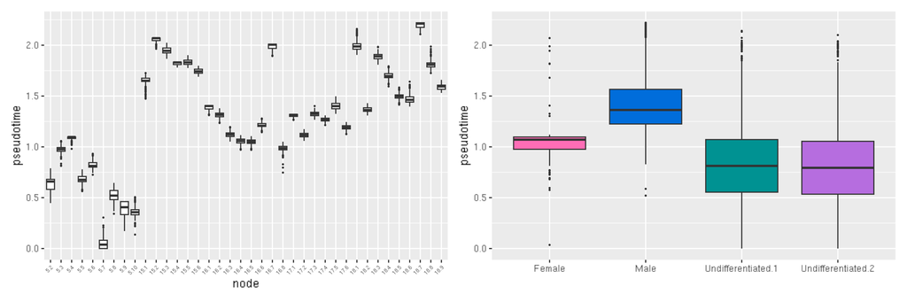

```r
pt_df = as.data.frame(colData(merged))

p_box_node = ggplot(pt_df, aes(x = node, y = pseudotime)) +
  geom_boxplot(outlier.size = .3) +
  theme(axis.text.x = element_text(angle = 45, hjust = 1, size = 5)) +
  xlab("node") + ylab("pseudotime")
p_box_lib = ggplot(pt_df, aes(x = library, y = pseudotime, fill = library)) +
  geom_boxplot(outlier.size = .3) +
  scale_fill_manual(values = lib_cols) +
  xlab(NULL) + ylab("pseudotime") +
  theme(legend.position = "none")

p_box_node | p_box_lib
```

```r
ggsave(p_box_node | p_box_lib,
       file = paste0(results_dir, "/pseudotime_by_node.png"),
       width = 12, height = 4, dpi = 600)
```

## Edge confidence

An MST always returns a tree. It connects every node whether or not the data supports the connection, so the shape on its own says nothing about how much of it is real.

Five columns describe each edge from a different direction.

| column | what it is | low | high |
| --- | --- | --- | --- |
| `length` | distance between the node centroids | nodes sit close together | nodes are far apart |
| `nn_rank_1`, `nn_rank_2` | each node’s place in the other’s distance-ordered list | 1 and 1: mutual nearest neighbors | the edge reaches past nearer nodes |
| `separation` | centroid distance in within-node standard deviations, measured along the line joining them | under 1: one continuous population | two distinguishable groups |
| `pct_of_cut` | length as a percentage of the outgroup threshold | the edge survives outgroup splitting | over 100: outgroup splitting removes it |
| `frequency` | percentage of subsampled trees holding the edge | another sample would not have drawn it | drawn whatever the sample |

`frequency` comes from drawing `edge_boot_cells` cells from each node `edge_boot` times, with replacement, recomputing the centroids and rebuilding the tree. The count is fixed per node rather than proportional. A node of 5,000 cells has a centroid so precisely estimated that dropping a fifth of them moves it almost not at all, so a proportional subsample returns close to 100 percent for every edge including the arbitrary ones. Replacement matters for the small nodes: drawn without it, a node holding fewer cells than `edge_boot_cells` is taken whole every time and its centroid cannot move. Read it as a stress test rather than as a p-value.

A low `separation` is expected between consecutive waypoints on a trajectory. It is the reading to question where the two nodes carry annotations for distinct cell types. Combined with the ranks it separates cases that look alike on the figure.

| `separation` | `nn_rank` | reading |
| --- | --- | --- |
| low | 1 and 1 | one continuous population, joined at its closest point |
| low | high | overlapping nodes, joined the long way round |
| high | 1 and 1 | two distinct groups with a genuine link between them |
| high | high | a long edge to a node that sits near nothing |

No column says whether a low `separation` means the annotation is wrong or the subclustering was cut too fine. That comes from the marker sets.

```r
edge_key = function(a, b) paste(pmin(a, b), pmax(a, b), sep = " -- ")

edge_tab = igraph::as_data_frame(pseudo$mst, what = "edges") %>%
  dplyr::rename(node_1 = from, node_2 = to) %>%
  dplyr::mutate(length = signif(weight, 3),
                key = edge_key(node_1, node_2))

# The outgroup rule, reported whether or not it is switched on. With
# outgroup = TRUE, createClusterMST puts an artificial node 1.5 times the median
# edge length away from every real node. An edge longer than that is beaten by a
# pair of edges through the outgroup, and deleting the outgroup leaves the tree
# in pieces. The median is taken from the tree built without an outgroup, which
# is the reference the package itself uses.
og_cut = if (is.numeric(params$outgroup)) {
  as.numeric(params$outgroup)
} else {
  ref = if (!isTRUE(params$outgroup)) edge_tab$length else {
    m0 = try(TrajectoryUtils::createClusterMST(
               reducedDim(merged, "corrected"),
               clusters    = as.character(merged$node),
               dist.method = as.character(params$dist_method),
               mnn.k       = params$mnn_k, outgroup = FALSE), silent = TRUE)
    if (inherits(m0, "try-error")) NULL else
      igraph::as_data_frame(m0, what = "edges")$weight
  }
  if (length(ref) == 0) NA_real_ else 1.5 * stats::median(ref)
}

# under 100 the edge survives outgroup splitting, over 100 it is cut
edge_tab$pct_of_cut = if (is.na(og_cut)) NA_real_ else
  round(100 * edge_tab$length / og_cut)

# Two reads on each edge that need no threshold, both from the node centroids of
# the corrected space.
#
#   nn_rank_1   where node_2 sits in node_1's list of nodes ordered by distance
#   nn_rank_2   where node_1 sits in node_2's
#   separation  centroid distance in standard deviations of the within-node
#               spread, so 2 means the centroids sit 2 SD apart
#
# Both are Euclidean, which is what dist.method = "simple" uses. Under any other
# dist.method they describe the corrected space rather than the distances the
# tree was built from.
co_all = reducedDim(merged, "corrected")
nd_all = as.character(merged$node)
cnt    = table(nd_all)
cent   = rowsum(co_all, nd_all)[names(cnt), , drop = FALSE] / as.vector(cnt)

# Within-node spread measured along the line joining the two centroids, which is
# the only direction the edge is about. Pooling the spread over all dimensions
# instead inflates this badly in a PC space: variance decays steeply across the
# dimensions, so an average over all fifty understates the spread along the few
# that separate the nodes. On simulated PC-like data a true two standard
# deviation gap reads 11.8 that way and 1.95 this way.
edge_separation = function(a, b) {
  ia = which(nd_all == a); ib = which(nd_all == b)
  if (length(ia) < 2 || length(ib) < 2) return(NA_real_)
  d = cent[b, ] - cent[a, ]
  L = sqrt(sum(d^2))
  if (!is.finite(L) || L == 0) return(NA_real_)
  u  = d / L
  va = stats::var(as.vector(co_all[ia, , drop = FALSE] %*% u))
  vb = stats::var(as.vector(co_all[ib, , drop = FALSE] %*% u))
  L / sqrt((va + vb) / 2)
}

node_dist = as.matrix(dist(cent))
diag(node_dist) = Inf
node_rank = t(apply(node_dist, 1, rank, ties.method = "min"))

edge_tab$nn_rank_1 = node_rank[cbind(edge_tab$node_1, edge_tab$node_2)]
edge_tab$nn_rank_2 = node_rank[cbind(edge_tab$node_2, edge_tab$node_1)]
edge_tab$separation = round(
  mapply(edge_separation, edge_tab$node_1, edge_tab$node_2), 2)

n_boot  = as.integer(params$edge_boot)
boot_ok = n_boot > 0

if (boot_ok) {
  co_b    = reducedDim(merged, "corrected")
  nd_b    = as.character(merged$node)
  by_node = split(seq_along(nd_b), nd_b)

  tally = table(unlist(lapply(seq_len(n_boot), function(i) {
    set.seed(1000 + i)
    # with replacement: a draw without it takes a node of 100 or fewer cells
    # whole every time, so its centroid never moves and its edges read 100 by
    # construction. Drawing with replacement gives every node the same centroid
    # precision whatever its size.
    keep = unlist(lapply(by_node, function(ix)
      sample(ix, max(2L, as.integer(params$edge_boot_cells)), replace = TRUE)))
    m = try(TrajectoryUtils::createClusterMST(
              co_b[keep, , drop = FALSE], clusters = nd_b[keep],
              dist.method = as.character(params$dist_method),
              mnn.k = params$mnn_k, outgroup = params$outgroup),
            silent = TRUE)
    if (inherits(m, "try-error")) return(NULL)
    e = igraph::as_data_frame(m, what = "edges")
    unique(edge_key(e$from, e$to))
  })))

  edge_tab$frequency = round(100 * as.integer(tally[edge_tab$key]) / n_boot)
  edge_tab$frequency[is.na(edge_tab$frequency)] = 0

  # edges the resampling drew that the full-data tree did not
  extra = setdiff(names(tally), edge_tab$key)
  extra_tab = if (length(extra) == 0) NULL else
    data.frame(edge = extra,
               frequency = round(100 * as.integer(tally[extra]) / n_boot),
               stringsAsFactors = FALSE) %>%
      dplyr::filter(frequency >= 10) %>%
      dplyr::arrange(dplyr::desc(frequency))
} else {
  edge_tab$frequency = NA_integer_
  extra_tab = NULL
}

edge_tab = edge_tab %>%
  dplyr::select(node_1, node_2, length, nn_rank_1, nn_rank_2, separation,
                pct_of_cut, frequency) %>%
  dplyr::arrange(dplyr::desc(is.na(frequency)), frequency, length)

write.csv(edge_tab, file = paste0(results_dir, "/mst_edges.csv"),
          row.names = FALSE)

# eight narrow columns: no paging unless the tree is large, numbers right
# aligned, and horizontal scroll rather than wrapped headers
datatable(edge_tab, rownames = FALSE, class = "compact stripe hover",
          options = list(dom = if (nrow(edge_tab) > 25) "tp" else "t",
                         paging = nrow(edge_tab) > 25, pageLength = 25,
                         scrollX = TRUE, autoWidth = FALSE,
                         columnDefs = list(list(className = "dt-right",
                                                targets = 2:7))))
```

| node_1 | node_2 | length | nn_rank_1 | nn_rank_2 | separation | pct_of_cut | frequency |
| --- | --- | --- | --- | --- | --- | --- | --- |
| 16.1 | 16.2 | 0.101 | 1 | 4 | 2.86 | 68 | 44 |
| 16.2 | 16.6 | 0.0972 | 2 | 3 | 2.98 | 65 | 53 |
| 17.4 | 17.6 | 0.0694 | 3 | 1 | 3.06 | 47 | 63 |
| 15.4 | 15.6 | 0.0915 | 1 | 2 | 3.35 | 62 | 63 |
| 18.4 | 18.9 | 0.102 | 2 | 2 | 3.7 | 69 | 65 |
| 15.3 | 15.5 | 0.114 | 1 | 4 | 3.36 | 77 | 68 |
| 15.1 | 18.6 | 0.176 | 6 | 11 | 4.01 | 119 | 77 |
| 18.5 | 18.9 | 0.0973 | 2 | 1 | 3.22 | 66 | 82 |
| 15.5 | 15.6 | 0.0897 | 1 | 1 | 3.29 | 60 | 83 |
| 16.3 | 16.6 | 0.0867 | 2 | 1 | 2.94 | 58 | 92 |

[output cut: 27 more lines]

The least confident edge is 16.1 to 16.2, drawn in 44 percent of 100 trees built from 100 cells per node. 1 of 37 edges appear in under half of them, and 20 in all of them.

```r
if (!is.null(extra_tab) && nrow(extra_tab) > 0)
  datatable(extra_tab, rownames = FALSE,
            options = list(pageLength = 10, scrollX = TRUE))
```

| edge | frequency |
| --- | --- |
| 15.4 -- 15.5 | 52 |
| 16.2 -- 16.3 | 41 |
| 17.1 -- 17.6 | 37 |
| 15.1 -- 15.3 | 32 |
| 16.1 -- 17.5 | 26 |
| 16.1 -- 18.9 | 25 |
| 16.1 -- 16.6 | 21 |
| 15.3 -- 18.6 | 20 |
| 18.2 -- 18.8 | 19 |
| 18.2 -- 18.4 | 18 |

[output cut: 1 more lines]

**11 edge(s) appear in at least 10 percent of the subsampled trees without appearing in the tree above.** Where a competing edge is drawn nearly as often as the one that was kept, the two are interchangeable and the tree picked one of them.

The outgroup threshold for this tree is 0.149, which is 1.5 times the median edge length. 10 of 37 edges are longer, the longest being 5.7 to 5.9 at 310 percent. Under outgroup = TRUE the tree is rebuilt with the artificial node present, so the pieces are not guaranteed to be this tree minus those edges.

8 of 37 edges join mutual nearest neighbors. 17 reach further than either node’s second nearest, the furthest being 5.2 to 16.8 at ranks 1 and 24. Every pair sits at least one standard deviation apart. The per-edge values are in mst_edges.csv.

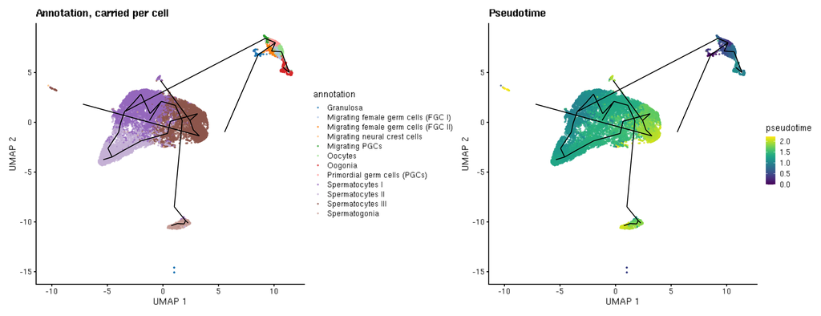

```r
by_node = aggregateAcrossCells(
  merged, ids = merged$node,
  use.assay.type = if ("reconstructed" %in% assayNames(merged))
    "reconstructed" else "logcounts")
edges_umap = reportEdges(by_node, mst = pseudo$mst, clusters = NULL,
                         use.dimred = "UMAP")

p_anno_umap = plotUMAP(merged, colour_by = "annotation", point_size = .4) +
  geom_line(data = edges_umap, aes(x = UMAP1, y = UMAP2, group = edge)) +
  ggtitle("Annotation, carried per cell")
p_pt_umap = plotUMAP(merged, colour_by = "pseudotime", point_size = .4) +
  geom_line(data = edges_umap, aes(x = UMAP1, y = UMAP2, group = edge)) +
  ggtitle("Pseudotime")

p_anno_umap | p_pt_umap
```

```r
ggsave(p_anno_umap | p_pt_umap,
       file = paste0(results_dir, "/trajectory_umap.png"), width = 13, height = 5)
```

## Node graph

Edge length on this figure is meaningful. The layout is weighted by the real distance between nodes, so a long edge means the two nodes are far apart in the corrected space. Those distances are the `length` column of `mst_edges.csv`. The reproduction is not exact, because a tree in fifty dimensions cannot always be drawn faithfully in two, but it is close to a uniform rescale rather than arbitrary. If the message about a failed layout appears above, the figure fell back to an unweighted layout and edge lengths mean nothing.

```r
node_stats = as.data.frame(colData(merged)) %>%
  dplyr::group_by(node) %>%
  dplyr::summarise(n_cells = dplyr::n(),
                   mean_pseudo = mean(pseudotime, na.rm = TRUE),
                   top_anno = names(sort(table(annotation),
                                         decreasing = TRUE))[1],
                   .groups = "drop") %>%
  dplyr::rename(name = node) %>%
  dplyr::mutate(name = as.character(name))

e_ig = igraph::as_data_frame(pseudo$mst, what = "edges") %>%
  dplyr::mutate(key = edge_key(from, to)) %>%
  dplyr::left_join(edge_tab %>%
                     dplyr::mutate(key = edge_key(node_1, node_2)) %>%
                     dplyr::select(key, frequency, pct_of_cut),
                   by = "key")
use_freq  = boot_ok && !anyNA(e_ig$frequency)

gr = as_tbl_graph(pseudo$mst) %>%
  activate(nodes) %>%
  left_join(node_stats, by = "name") %>%
  activate(edges) %>%
  mutate(conf = if (use_freq) as.numeric(e_ig$frequency) else NA_real_,
         cut_pct = as.numeric(e_ig$pct_of_cut))

# Layout by real distance. The stress layout ignores edge weights by default and
# draws every edge at roughly the same length, so the picture says nothing about
# how far apart nodes are. graphlayouts treats weights as similarities, not
# distances, so the reciprocal is what is passed: a long edge then has a weak
# pull and is drawn long. On test trees this reproduces the true edge lengths to
# a near-uniform scale factor, correlation 0.999. It also survives a tree split
# into components, which a distance-matrix layout does not.
layout_by_distance = function(graph, lengths) {
  w = as.numeric(lengths)
  w[!is.finite(w) | w <= 0] = min(w[is.finite(w) & w > 0], na.rm = TRUE) / 1000
  out = try(create_layout(graph, layout = "stress", weights = 1 / w), silent = TRUE)
  if (inherits(out, "try-error")) {
    message("distance-weighted layout failed; falling back to plain stress, ",
            "so edge lengths on the figure will not be meaningful")
    out = create_layout(graph, layout = "stress")
  }
  out
}

set.seed(1)
lay = layout_by_distance(gr, e_ig$weight)

# The coordinates, so another document can draw this same tree rather than
# computing a layout of its own and showing a different picture of it. The
# edges are already in mst_edges.csv, so the pair is enough to redraw it.
write.csv(data.frame(node = as.character(lay$name),
                     x = lay$x, y = lay$y, stringsAsFactors = FALSE),
          file = paste0(results_dir, "/node_graph_layout.csv"),
          row.names = FALSE)

# edge color is the subsampling frequency, so an edge a different sample would
# not have drawn reads as red
lay_d = as.matrix(dist(as.matrix(lay[, c("x", "y")])))
diag(lay_d) = Inf
lay_span = max(diff(range(lay$x)), diff(range(lay$y)))
# node sizes scaled to how tightly the distance-faithful layout packs them
size_hi = max(2.5, min(9, 55 * min(lay_d) / lay_span))

# color alone; width carried no information color was not already carrying
# Edge colour is the length as a percentage of the outgroup threshold, not the
# subsampling frequency. Frequency reads 100 for an edge the tree was forced to
# draw, because a node that belongs nowhere is attached to the same place in
# every resample. The threshold says how long the edge is, which that cannot
# hide. Blue is short, red is past the threshold; the numbers are in
# mst_edges.csv along with the frequency.
use_cut  = !all(is.na(e_ig$pct_of_cut))
# Edges are drawn as shallow arcs and stopped short of the node glyphs. Drawn
# straight and to the centers, a long edge passing near an unrelated node looks
# like it terminates there, and a chain then reads as a cycle the tree cannot
# contain. The bow costs about one percent in drawn length against the straight
# chord, far less than the layout already approximates.
edge_cap = circle(2.2, "mm")
edge_aes = list(
  if (use_cut) geom_edge_arc(aes(edge_colour = cut_pct), edge_width = .9,
                             strength = 0.12,
                             start_cap = edge_cap, end_cap = edge_cap)
    else geom_edge_arc(edge_colour = "grey55", edge_width = .9,
                       strength = 0.12,
                       start_cap = edge_cap, end_cap = edge_cap),
  if (use_cut) scale_edge_colour_gradient2(low = "#2166ac", mid = "#bdbdbd",
                  high = "#b2182b", midpoint = 100,
                  name = "% of the outgroup\nthreshold") else NULL)

g_pt = ggraph(lay) +
  edge_aes +
  geom_node_point(aes(size = n_cells, colour = mean_pseudo)) +
  geom_node_text(aes(label = name), size = 2.1, repel = TRUE) +
  scale_colour_viridis_c() +
  scale_size_continuous(range = c(max(1, size_hi / 4), size_hi)) +
  theme_void(base_size = 9) +
  coord_fixed() + labs(colour = "mean pseudotime", size = "cells")

g_an = ggraph(lay) +
  edge_aes +
  geom_node_point(aes(size = n_cells, colour = top_anno)) +
  geom_node_text(aes(label = name), size = 2.1, repel = TRUE) +
  scale_size_continuous(range = c(max(1, size_hi / 4), size_hi)) +
  theme_void(base_size = 9) +
  coord_fixed() + labs(colour = "most common annotation", size = "cells")

p_node_graph = (g_pt / g_an) +
  patchwork::plot_layout(guides = "collect") +
  patchwork::plot_annotation(tag_levels = "A") &
  theme(legend.position = "right", legend.box = "vertical",
        legend.key.size = unit(.4, "cm"),
        legend.title = element_text(size = 8),
        legend.text  = element_text(size = 7),
        plot.tag     = element_text(size = 11, face = "bold"))

p_node_graph
```

[figure not shown]

```r
ggsave(p_node_graph, file = paste0(results_dir, "/node_graph.png"),
       width = 11, height = 13, dpi = 300)
ggsave(p_node_graph, file = paste0(results_dir, "/node_graph.pdf"),
       width = 11, height = 13)
```

Panel B labels each node by whichever annotation holds the most of its cells. That is a summary, not a claim about the node: a node can be 51 percent one annotation and still be mixed. The full composition is in the stacked bar above and in node_by_annotation.csv.

## Which node reached for which

Each pair is drawn twice, once in each direction. An arrow from A to B is colored by where B sits in A’s list of nodes ordered by distance, so an edge blue in both directions joins mutual nearest neighbors. An arrow that is blue one way and red the other is a node reaching for a partner that is not reaching back: the tail node had to attach somewhere and this was its best option, while the head node has many closer neighbors.

This is the reading the edge frequency cannot give. A forced attachment is drawn in every resample, so it scores 100 percent there while showing red here.

```r
# Two directed edges per pair, each colored by how the node it points to ranks
# among the neighbors of the node it leaves. Node positions are taken from the
# layout above so the two figures can be read against each other.
dir_edges = dplyr::bind_rows(
  edge_tab %>% dplyr::transmute(from = node_1, to = node_2, rank = nn_rank_1),
  edge_tab %>% dplyr::transmute(from = node_2, to = node_1, rank = nn_rank_2))

gr_dir  = tidygraph::tbl_graph(
  nodes = data.frame(name = lay$name, stringsAsFactors = FALSE),
  edges = dir_edges, directed = TRUE)
lay_dir = create_layout(gr_dir, layout = "manual", x = lay$x, y = lay$y)

g_rank = ggraph(lay_dir) +
  geom_edge_fan(aes(edge_colour = rank),
                arrow = grid::arrow(length = unit(1.8, "mm"), type = "closed"),
                start_cap = circle(2, "mm"), end_cap = circle(2.4, "mm"),
                edge_width = .8) +
  scale_edge_colour_gradient(low = "#2166ac", high = "#b2182b", trans = "log10",
                             name = "rank of the node\nthe arrow points to") +
  geom_node_point(size = max(1.5, size_hi * .5), colour = "grey30") +
  geom_node_text(aes(label = name), size = 2.6, repel = TRUE,
                 max.overlaps = Inf, box.padding = .5, point.padding = .25,
                 min.segment.length = 0, segment.size = .15,
                 segment.colour = "grey65", seed = 1) +
  scale_x_continuous(expand = expansion(mult = .08)) +
  scale_y_continuous(expand = expansion(mult = .08)) +
  coord_fixed() +
  theme_void(base_size = 9) +
  theme(legend.position = "right", legend.key.size = unit(.4, "cm"),
        legend.title = element_text(size = 8), legend.text = element_text(size = 7))

g_rank
```

[figure not shown]

```r
ggsave(g_rank, file = paste0(results_dir, "/node_graph_ranks.png"),
       width = 13, height = 12, dpi = 300)
ggsave(g_rank, file = paste0(results_dir, "/node_graph_ranks.pdf"),
       width = 13, height = 12)
```

## Marker sets on the tree

The same tree, once per germ cell marker set. Color is the set’s mean log expression scaled to its own maximum, so the panels show where each program sits rather than how the programs compare with one another. Size is the percentage of cells in the node detecting the set.

Each panel title carries the set’s absolute maximum. A panel whose maximum is near zero is showing noise stretched across the full color range, so read the title before the colors. The unscaled values are in `node_marker_set_scores.csv`.

```r
graph_sets = trimws(strsplit(as.character(params$graph_marker_sets), ",")[[1]])
graph_sets = intersect(graph_sets[nzchar(graph_sets)], unique(set_scores$set))

set_panel = function(st) {
  sc = set_scores %>% dplyr::filter(set == st)
  mx = suppressWarnings(max(sc$mean_logexpr, na.rm = TRUE))
  ld = lay
  ld$rel = if (is.finite(mx) && mx > 0)
    sc$mean_logexpr[match(ld$name, as.character(sc$node))] / mx else NA_real_
  ld$pct = sc$pct_detected[match(ld$name, as.character(sc$node))]

  ggraph(ld) +
    edge_aes +
    geom_node_point(aes(colour = rel, size = pct)) +
    geom_node_text(aes(label = name), size = 2.4, repel = TRUE,
                   max.overlaps = Inf, box.padding = .45,
                   point.padding = .2, min.segment.length = 0,
                   segment.size = .15, segment.colour = "grey65",
                   seed = 1) +
    # inferno, because viridis is pseudotime everywhere else in this document.
    # Its top tenth is near white and would vanish on the page, so it stops short.
    scale_colour_viridis_c(name = "expression, relative\nto the set maximum",
                           option = "inferno", end = .9, limits = c(0, 1)) +
    scale_size_continuous(name = "% of cells detecting",
                          range = c(1, 4.5), limits = c(0, 100)) +
    scale_x_continuous(expand = expansion(mult = .10)) +
    scale_y_continuous(expand = expansion(mult = .10)) +
    coord_fixed() +
    theme_void(base_size = 8) +
    ggtitle(sprintf("%s  (max %.2f)", st, mx)) +
    theme(plot.title = element_text(size = 8, hjust = .5))
}

if (length(graph_sets) > 0) {
  p_set_graph = patchwork::wrap_plots(lapply(graph_sets, set_panel),
                                      ncol = min(2, length(graph_sets))) +
    patchwork::plot_layout(guides = "collect") &
    theme(legend.position = "right", legend.box = "vertical",
          legend.key.size = unit(.35, "cm"),
          legend.title = element_text(size = 7),
          legend.text  = element_text(size = 6))

  # print(), not a bare name: inside a block only the last value is returned,
  # so a bare plot object in the middle of one draws nothing
  print(p_set_graph)
  ggsave(p_set_graph, file = paste0(results_dir, "/node_graph_marker_sets.png"),
         width = 14, height = 12, dpi = 300)
  ggsave(p_set_graph, file = paste0(results_dir, "/node_graph_marker_sets.pdf"),
         width = 14, height = 12)
}
```

[figure not shown]

## Figure 6

```r
# panel letter to set; all three are in germ_sets, so set_scores always has them
fig6_sets = c(B = "Primordial germ cells", C = "Spermatocytes", D = "Oocyte")

# nodes off every path have no pseudotime and so no place on the y axis
fig6_nodes = node_stats %>%
  dplyr::filter(is.finite(mean_pseudo)) %>%
  dplyr::arrange(mean_pseudo)
# earliest at the top
fig6_levels = rev(fig6_nodes$name)

fig6_lib = as.data.frame(colData(merged)) %>%
  dplyr::mutate(node = as.character(node)) %>%
  dplyr::filter(node %in% fig6_levels) %>%
  dplyr::count(node, library, name = "n") %>%
  dplyr::group_by(node) %>%
  dplyr::mutate(frac = n / sum(n)) %>%
  dplyr::ungroup() %>%
  dplyr::mutate(node = factor(node, levels = fig6_levels))

write.csv(fig6_lib %>%
            dplyr::left_join(fig6_nodes %>%
                               dplyr::select(node = name, mean_pseudotime = mean_pseudo),
                             by = "node") %>%
            dplyr::arrange(mean_pseudotime, library),
          file = paste0(results_dir, "/figure6_node_by_library.csv"),
          row.names = FALSE)

# the gene symbols of each set, for the legend
fig6_genes = all_sets %>%
  dplyr::filter(CellTypeMarkerSet %in% fig6_sets,
                loc_id %in% rownames(combined)) %>%
  dplyr::distinct(CellTypeMarkerSet, symbol) %>%
  dplyr::group_by(CellTypeMarkerSet) %>%
  dplyr::summarise(symbols = paste(sort(symbol), collapse = ", "), .groups = "drop")
fig6_symbols = setNames(fig6_genes$symbols, fig6_genes$CellTypeMarkerSet)
```

```r
p_fig6_strip = ggplot(fig6_nodes %>%
                        dplyr::mutate(name = factor(name, levels = fig6_levels)),
                      aes(x = 1, y = name, fill = mean_pseudo)) +
  geom_tile() +
  scale_fill_viridis_c(name = "mean pseudotime") +
  scale_x_continuous(expand = c(0, 0)) +
  theme_minimal(base_size = 8) +
  theme(axis.text.x = element_blank(), axis.ticks = element_blank(),
        panel.grid = element_blank(),
        axis.text.y = element_text(size = 6)) +
  labs(x = NULL, y = NULL)

p_fig6_lib = ggplot(fig6_lib, aes(x = frac, y = node, fill = library)) +
  geom_col(width = .85) +
  scale_fill_manual(values = lib_cols) +
  scale_x_continuous(expand = c(0, 0), labels = scales::percent) +
  theme_bw(base_size = 8) +
  theme(axis.text.y = element_blank(), axis.ticks.y = element_blank(),
        panel.grid.major.y = element_blank()) +
  labs(x = "cells in the node", y = NULL, fill = "library")

p_fig6_a = (p_fig6_strip | p_fig6_lib) +
  patchwork::plot_layout(widths = c(.05, 1), guides = "collect")

p_fig6 = patchwork::wrap_plots(p_fig6_a, set_panel(fig6_sets[["B"]]),
                               set_panel(fig6_sets[["C"]]),
                               set_panel(fig6_sets[["D"]]), ncol = 2) +
  patchwork::plot_layout(guides = "collect") +
  # the strip takes the A, the bars beside it take none
  patchwork::plot_annotation(tag_levels = list(c("A", "", "B", "C", "D"))) &
  theme(legend.position = "right", legend.box = "vertical",
        legend.key.size = unit(.35, "cm"),
        legend.title = element_text(size = 7),
        legend.text  = element_text(size = 6),
        plot.tag     = element_text(size = 11, face = "bold"))

p_fig6
```

[figure not shown]

```r
ggsave(p_fig6, file = paste0(results_dir, "/figure6.png"),
       width = 14, height = 13, dpi = 300)
ggsave(p_fig6, file = paste0(results_dir, "/figure6.pdf"),
       width = 14, height = 13)
```

**Figure 6. Library composition and germ cell marker sets along the trajectory.** **(A)** Library composition of the 38 trajectory nodes. Nodes are on the y axis, ordered by the mean pseudotime of their cells, with the earliest at the top. Each bar is the percentage of the node’s cells from each library. The strip beside the axis is colored by the node’s mean pseudotime. **(B-D)** The node graph colored by the Primordial germ cells (B; ALPL, DDX4, PRDM1, PRDM14), Spermatocytes (C; BOLL, DMC1, SYCP3, TEX11, TEX15) and Oocyte (D; DDX4, LHX8, ZAR1L, ZP2, ZP3, ZP4) marker sets. Node color is the set’s mean log expression, scaled to the set’s maximum across nodes. That maximum is given in each panel title. Point size is the mean, over the set’s genes, of the percentage of the node’s cells detecting the gene. Node positions are the distance-weighted layout of the node graph, so edge length approximates the distance between node centroids in the corrected space. Edge color is the edge’s length as a percentage of the outgroup threshold.

# What the ordering says

This is where the trajectory is interpreted, and it is done from the cells rather than from node names. The annotation is the collaborators’ expert call carried by barcode, so its distribution along pseudotime is the claim.

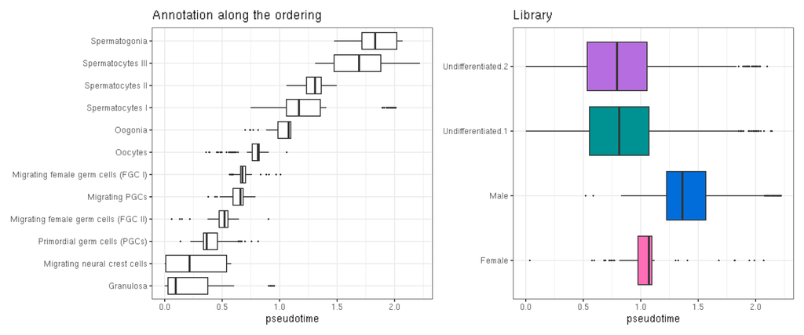

```r
pt_df = as.data.frame(colData(merged))
pt_df$barcode = colnames(merged)

p_anno_pt = ggplot(pt_df %>% dplyr::filter(!is.na(pseudotime)),
                   aes(x = pseudotime, y = reorder(annotation, pseudotime,
                                                   FUN = median))) +
  geom_boxplot(outlier.size = .2) +
  theme_bw() + labs(x = "pseudotime", y = NULL,
                    title = "Annotation along the ordering")
p_lib_pt = ggplot(pt_df %>% dplyr::filter(!is.na(pseudotime)),
                  aes(x = pseudotime, y = library, fill = library)) +
  geom_boxplot(outlier.size = .2) +
  scale_fill_manual(values = lib_cols) +
  theme_bw() + theme(legend.position = "none") +
  labs(x = "pseudotime", y = NULL, title = "Library")

p_anno_pt | p_lib_pt
```

```r
ggsave(p_anno_pt | p_lib_pt,
       file = paste0(results_dir, "/pseudotime_by_annotation.png"),
       width = 12, height = 5)
```

```r
anno_order = pt_df %>%
  dplyr::filter(!is.na(pseudotime)) %>%
  dplyr::group_by(annotation) %>%
  dplyr::summarise(n_cells = dplyr::n(),
                   median_pseudotime = signif(median(pseudotime), 3),
                   q1 = signif(quantile(pseudotime, .25), 3),
                   q3 = signif(quantile(pseudotime, .75), 3),
                   .groups = "drop") %>%
  dplyr::arrange(median_pseudotime)

write.csv(anno_order, file = paste0(results_dir, "/annotation_pseudotime.csv"),
          row.names = FALSE)

datatable(anno_order, rownames = FALSE, options = list(dom = "t", paging = FALSE))
```

| annotation | n_cells | median_pseudotime | q1 | q3 |
| --- | --- | --- | --- | --- |
| Granulosa | 192 | 0.0958 | 0.0287 | 0.375 |
| Migrating neural crest cells | 8 | 0.216 | 0.00962 | 0.538 |
| Primordial germ cells (PGCs) | 188 | 0.365 | 0.337 | 0.458 |
| Migrating female germ cells (FGC II) | 284 | 0.521 | 0.473 | 0.55 |
| Migrating PGCs | 149 | 0.659 | 0.594 | 0.682 |
| Migrating female germ cells (FGC I) | 204 | 0.676 | 0.66 | 0.703 |
| Oocytes | 298 | 0.811 | 0.761 | 0.822 |
| Oogonia | 392 | 1.08 | 0.985 | 1.1 |
| Spermatocytes I | 5622 | 1.17 | 1.06 | 1.35 |
| Spermatocytes II | 3950 | 1.31 | 1.23 | 1.36 |

[output cut: 2 more lines]

## How much of the ordering is the library

Cells from four libraries are ordered along one axis, and two of those libraries are larvae while two are transformers. An ordering that only separated the libraries would reproduce the sample sheet rather than describe development. This asks how much of it does that.

Pseudotime is regressed on library, and separately on stage. For a categorical predictor the R squared of that regression is the share of the total spread in pseudotime that sits between the groups rather than within them. At 1 every library would occupy its own band with no overlap, and naming the library would tell you a cell’s pseudotime. At 0 every library would cover the same range, and the whole ordering would be among cells from the same animal. Neither number is a p-value. With tens of thousands of cells the between-library difference is certain to be nonzero, and the question is how large it is.

The libraries nest inside stage, each being one stage throughout, so the library figure can only be the larger of the two. The difference between them is what separating four libraries adds over separating two stages, which here is batch and sex.

The trajectory is fitted in the corrected space, where fastMNN has already pulled the libraries onto each other. A low figure here is a check on that correction rather than independent evidence that the ordering is developmental: a high one would say the correction had failed and the ordering was separating animals. Evidence from outside this dataset is in `16_bulk_validation.Rmd`, where genes ordered by this pseudotime are tested against a bulk series collected by a different group.

```r
pt_var   = pseudotime_variance(pt_df, lib_cols)
lib_r2   = pt_var$lib_r2
stage_r2 = pt_var$stage_r2

pt_var$figure
```

[figure not shown]

```r
ggsave(pt_var$figure,
       file = paste0(results_dir, "/pseudotime_variance_by_library.png"),
       width = 7, height = 5, dpi = 300)

write.csv(pt_var$parts,
          file = paste0(results_dir, "/pseudotime_variance_by_library.csv"),
          row.names = FALSE)
```

Library explains 27.7% of the variance in pseudotime, and stage explains 25%. 72.3% is variation among cells from the same library, which is the part of the ordering the sample sheet does not account for.

The upper panel is where the number comes from. A library whose cells cover the full range contributes little to it, and one confined to a narrow band contributes a lot.

## What else the ordering tracks

Pooled across libraries, a trend can be the libraries sitting at different ends of the tree. The within-library figures cannot be that.

```r
# qc is built under Depth and technical content, before any removal, so it is
# joined by barcode rather than bound by position
qc = qc %>%
  dplyr::inner_join(data.frame(barcode = colnames(merged),
                               pseudotime = merged$pseudotime,
                               stringsAsFactors = FALSE), by = "barcode") %>%
  dplyr::filter(!is.na(pseudotime))

conf_measures = c("total", "detected", "pct_mito", "pct_rrna", "pct_ribo")
conf_stats = function(d, label) {
  if (nrow(d) < 20) return(NULL)
  dplyr::bind_rows(lapply(conf_measures, function(v) {
    ok = is.finite(d[[v]]) & is.finite(d$pseudotime)
    if (sum(ok) < 20) return(NULL)
    x = if (v %in% c("total", "detected")) log10(d[[v]][ok]) else d[[v]][ok]
    if (stats::sd(x) == 0) return(NULL)
    ct = suppressWarnings(cor.test(x, d$pseudotime[ok], method = "spearman"))
    data.frame(within = label, measure = v, n_cells = sum(ok),
               r2 = signif(summary(lm(d$pseudotime[ok] ~ x))$r.squared, 3),
               spearman_rho = signif(unname(ct$estimate), 3),
               p = signif(ct$p.value, 3), stringsAsFactors = FALSE)
  }))
}

conf_tab = dplyr::bind_rows(
  conf_stats(qc, "all cells"),
  dplyr::bind_rows(lapply(sort(unique(qc$library)), function(lb)
    conf_stats(qc[qc$library == lb, , drop = FALSE], lb))))

write.csv(conf_tab, file = paste0(results_dir, "/pseudotime_vs_technical.csv"),
          row.names = FALSE)

datatable(conf_tab, rownames = FALSE, options = list(pageLength = 15))
```

| within | measure | n_cells | r2 | spearman_rho | p |
| --- | --- | --- | --- | --- | --- |
| all cells | total | 17057 | 0.0544 | -0.101 | 7.85e-40 |
| all cells | detected | 17057 | 0.0552 | -0.116 | 5.8e-52 |
| all cells | pct_mito | 17057 | 0.229 | 0.355 | 0 |
| all cells | pct_rrna | 17057 | 0.0494 | -0.257 | 3.049999999999998e-256 |
| all cells | pct_ribo | 17057 | 0.166 | 0.14 | 4.44e-75 |
| Female | total | 427 | 8.52e-05 | 0.249 | 1.87e-07 |
| Female | detected | 427 | 0.000128 | 0.207 | 1.57e-05 |
| Female | pct_mito | 427 | 0.174 | -0.226 | 2.3e-06 |
| Female | pct_rrna | 427 | 0.00284 | -0.438 | 1.78e-21 |
| Female | pct_ribo | 427 | 0.164 | -0.517 | 1.38e-30 |

[output cut: 15 more lines]

Pooled, the strongest is pct_mito at 22.9 percent of the variance in pseudotime. Within libraries the same measure gives Female 17.4 percent, Male 2.1 percent, Undifferentiated.1 24.7 percent, Undifferentiated.2 26.1 percent. A pooled figure much larger than the within-library ones is the libraries at different ends of the tree rather than a gradient along it.

# Pseudotime-associated genes

```r
have_pt = sum(!is.na(merged$pseudotime)) > 20
```

```r
# Uncorrected log counts, as in 17. merged is the fastMNN output and carries
# reconstructed rather than logcounts, so it cannot be tested directly. Passing
# the path matrix rather than one vector tests each path on its own cells.
stopifnot(identical(colnames(combined), colnames(merged)))
pt_res = testPseudotime(combined, pseudotime = pseudo_mat)

pt_tab = dplyr::bind_rows(lapply(seq_along(pt_res), function(i) {
  as.data.frame(pt_res[[i]]) %>%
    tibble::rownames_to_column("Gene") %>%
    dplyr::mutate(Path = names(pt_res)[i])
})) %>%
  dplyr::filter(!is.na(FDR), FDR < params$fdr_cut) %>%
  dplyr::left_join(gene_description, by = "Gene") %>%
  dplyr::mutate(Direction = ifelse(logFC > 0, "up", "down")) %>%
  dplyr::arrange(Path, FDR) %>%
  dplyr::select(Path, Direction, Gene, WangGeneID, description,
                logFC, p.value, FDR)

write.csv(pt_tab, file = paste0(results_dir, "/pseudotime_genes.csv"),
          row.names = FALSE)

datatable(pt_tab %>% dplyr::mutate(dplyr::across(where(is.numeric),
                                                 ~signif(., 3))),
          rownames = FALSE, filter = "top", options = list(pageLength = 15))
```

| Path | Direction | Gene | WangGeneID | description | logFC | p.value | FDR |
| --- | --- | --- | --- | --- | --- | --- | --- |
| 15.2 | up | RPS17 | RPS17 | ribosomal protein S17 | 0.484 | 0 | 0 |
| 15.2 | down | LOC116950069 | LOC116950069 | uncharacterized LOC116950069, transcript variant X3 | -0.533 | 0 | 0 |
| 15.2 | down | LOC116941712 | OAZ2 | ornithine decarboxylase antizyme 2-like | -0.497 | 0 | 0 |
| 15.2 | up | CCNB2 | CCNB2 | cyclin B2 | 1.76 | 0 | 0 |
| 15.2 | up | RPL4 | RPL4 | ribosomal protein L4 | 0.156 | 0 | 0 |
| 15.2 | up | KIF23 | KIF23 | kinesin family member 23, transcript variant X1 | 0.373 | 0 | 0 |
| 15.2 | down | FDPS | FDPS | farnesyl diphosphate synthase | -0.603 | 0 | 0 |
| 15.2 | down | LOC116944937 | H2 | boophilin-H2-like | -0.35 | 0 | 0 |
| 15.2 | down | LOC116945539 | TUBA8 | tubulin alpha-8 chain-like | -0.125 | 0 | 0 |
| 15.2 | up | LOC116947166 | CDK2.1 | cyclin-dependent kinase 2-like | 1.47 | 0 | 0 |

[output cut: 77456 more lines]

77466 gene-path results at FDR < 0.01, over 8 path(s).

## Heatmaps

The 25 most significant genes in each direction along each path. Cells are restricted to that path and ordered by their position on it, so a cell on two paths appears in both panels at the place each path puts it.

```r
for (pth in colnames(pseudo_mat)) {
  on_path = rownames(pseudo_mat)[!is.na(pseudo_mat[, pth])]
  if (length(on_path) < 20) next

  # the bar is scaled within the path, so ordering and color both describe this
  # path rather than the average over all of them
  pv  = pseudo_mat[on_path, pth]
  rng = range(pv, na.rm = TRUE)
  combined$pseudotime_scaled = NA_real_
  combined$pseudotime_scaled[match(on_path, colnames(combined))] =
    if (diff(rng) > 0) (pv - rng[1]) / diff(rng) else 0

  for (dir in c("up", "down")) {
    top = pt_tab %>%
      dplyr::filter(Path == pth, Direction == dir) %>%
      dplyr::arrange(FDR, dplyr::desc(abs(logFC))) %>%
      dplyr::slice_head(n = 25)
    # hclust on the gene rows needs at least two of them
    if (nrow(top) < 2) next

    labs_wang = ifelse(is.na(top$WangGeneID), top$Gene, top$WangGeneID)
    hm = plot_pseudotime_heatmap(combined, top$Gene, labs_wang, on_path,
                                 pseudotime_column = "pseudotime_scaled")
    # guides = "collect" is what the function sets; rebuilding to change the
    # heights would drop it and clip the pseudotime legend title away
    hp = (hm[[1]] / hm[[2]]) +
      plot_layout(heights = c(0.03, 1), guides = "collect")

    f = paste0(results_dir, "/pseudotime_heatmap_",
               gsub("[^A-Za-z0-9]+", "_", pth), "_", dir, ".png")
    ggsave(hp, file = f, width = 7, height = 5, dpi = 600)

    # the heading starts with a word: pandoc drops everything before the first
    # letter when it builds anchor ids, so "5.1, up" would become "up"
    cat("\n\n### Path ", pth, ", ", dir, "\n\n", sep = "")
    cat("![](", f, ")\n\n", sep = "")
  }
}
```

### Path 5.9, up

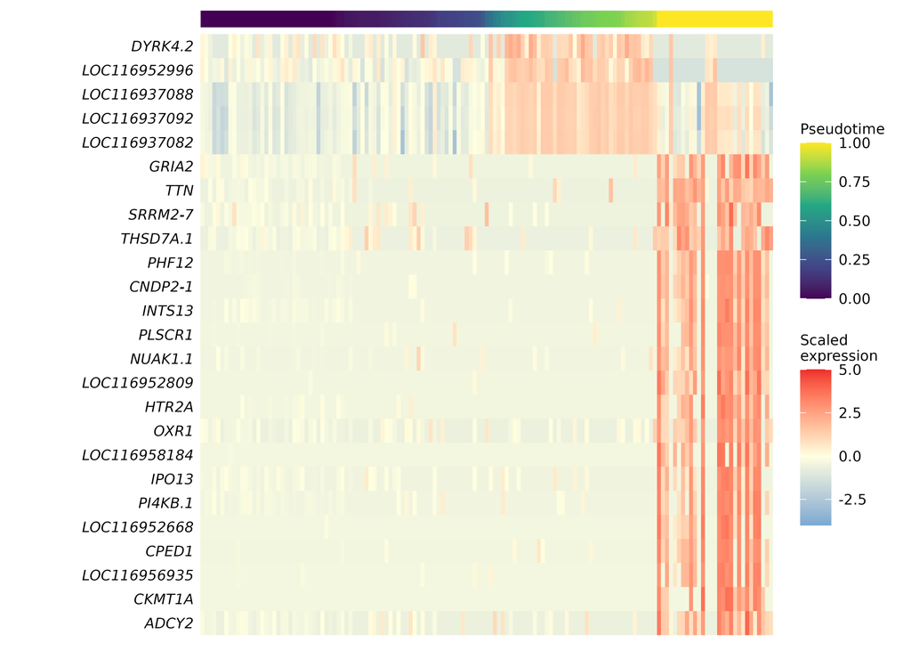

### Path 5.9, down

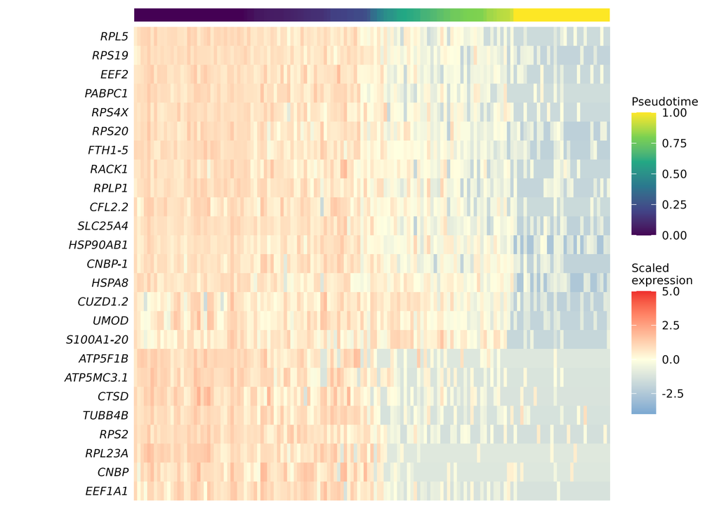

### Path 5.4, up

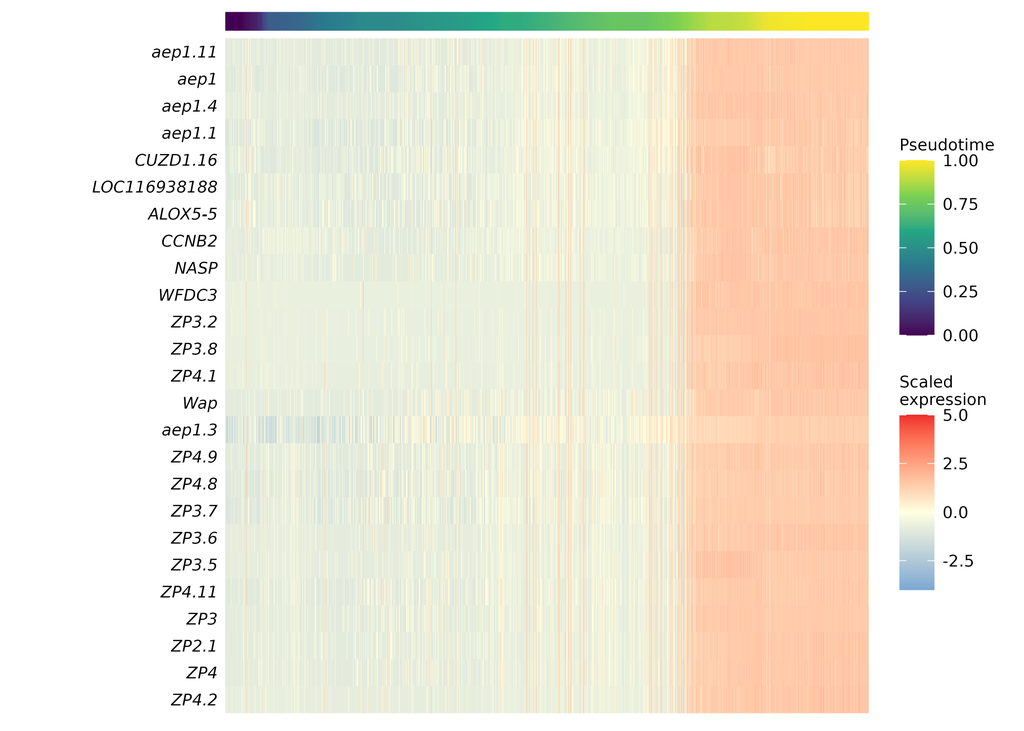

### Path 5.4, down

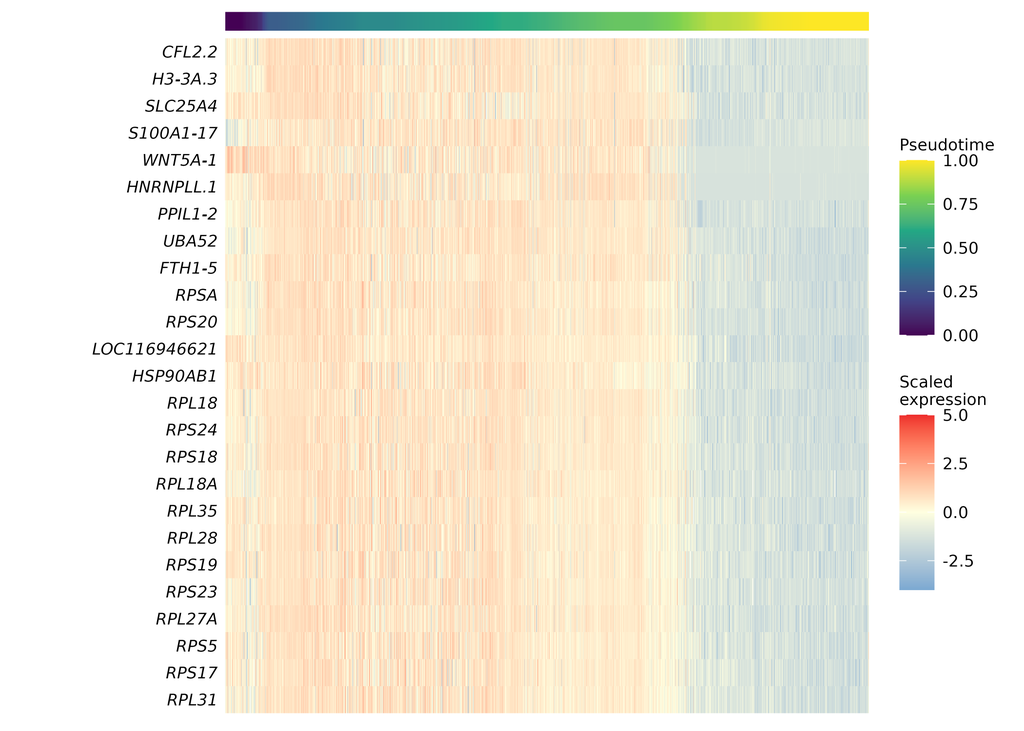

### Path 17.1, up

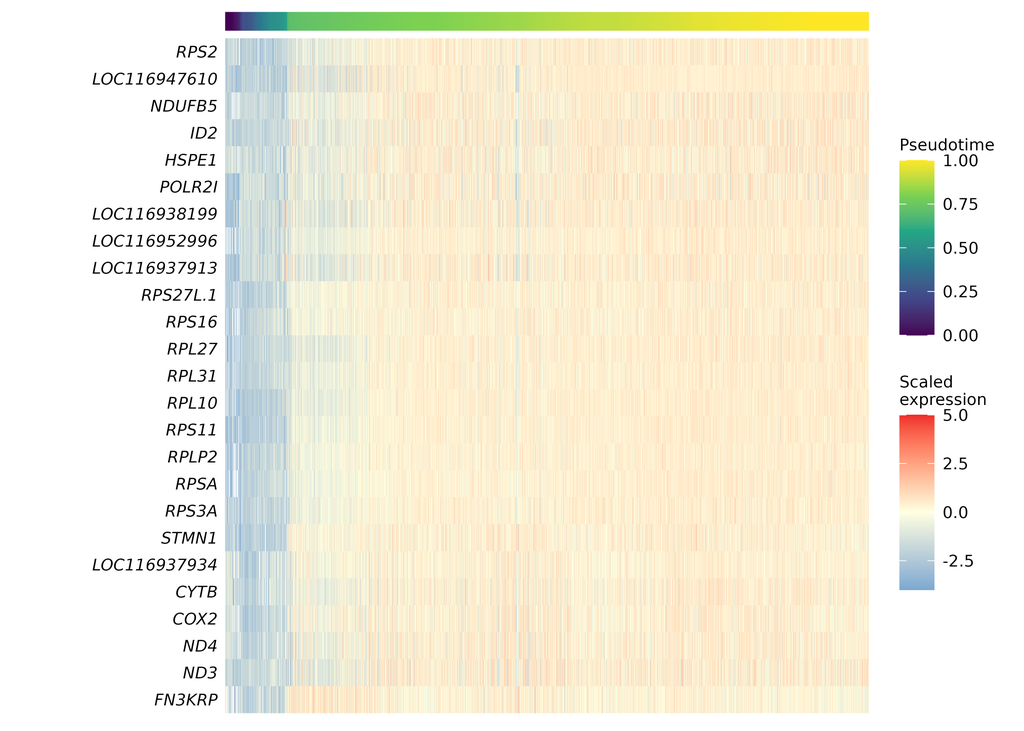

### Path 17.1, down

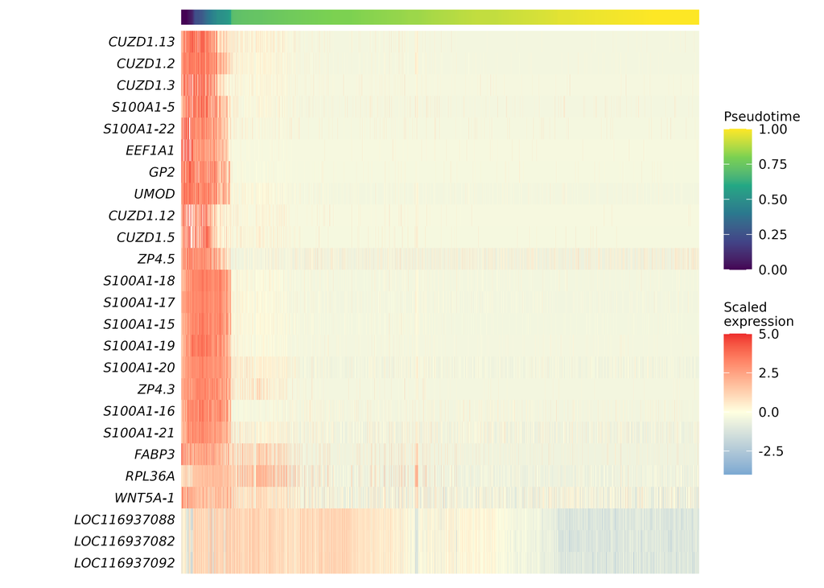

### Path 16.1, up

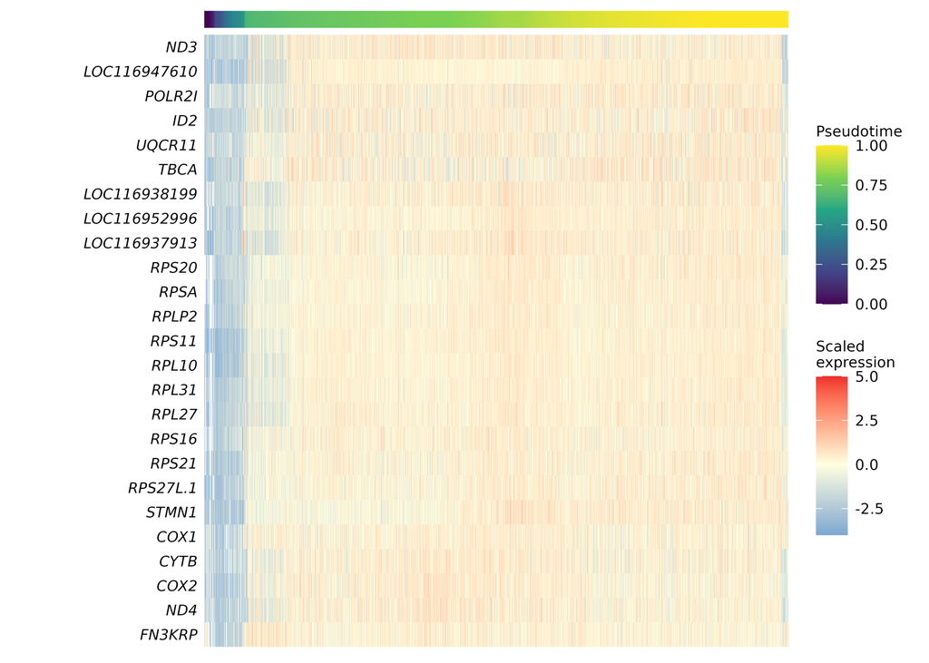

### Path 16.1, down

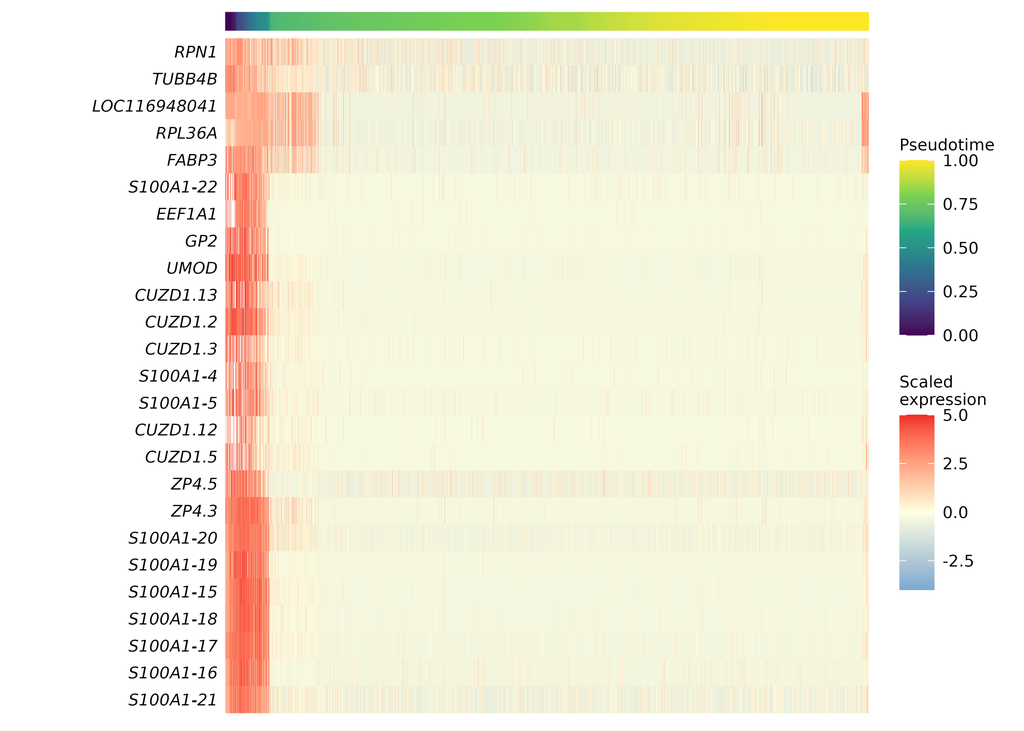

### Path 15.4, up

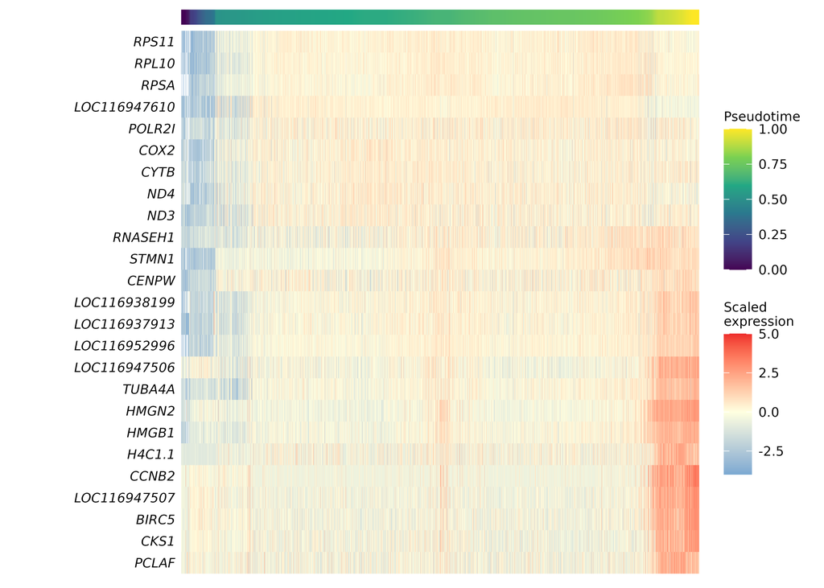

### Path 15.4, down

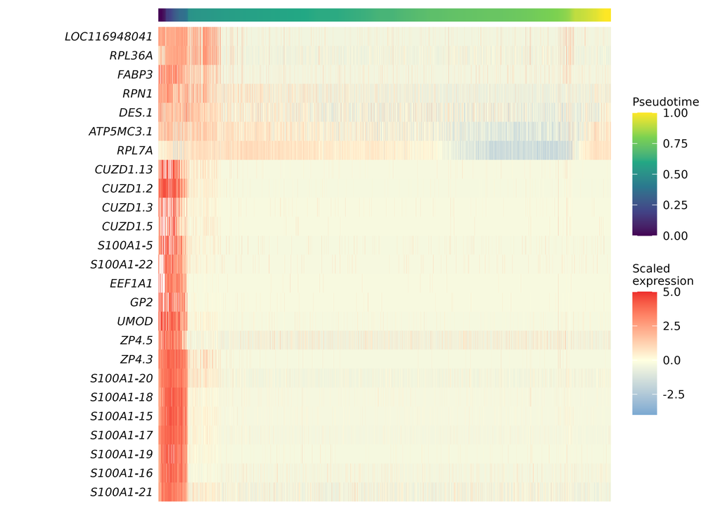

### Path 16.7, up

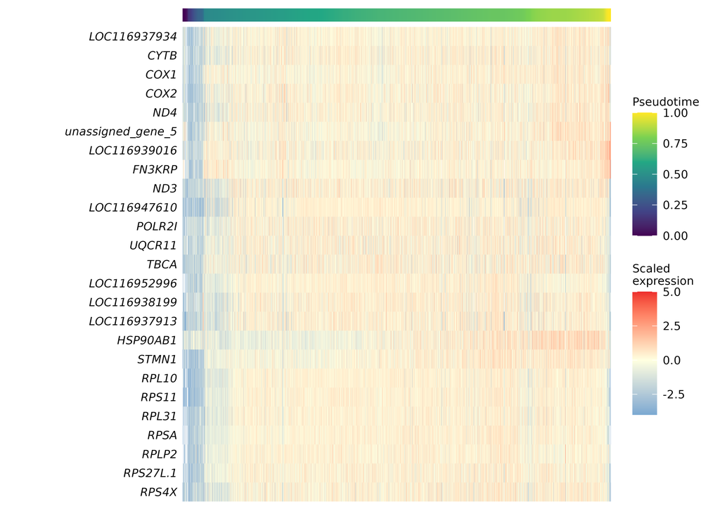

### Path 16.7, down

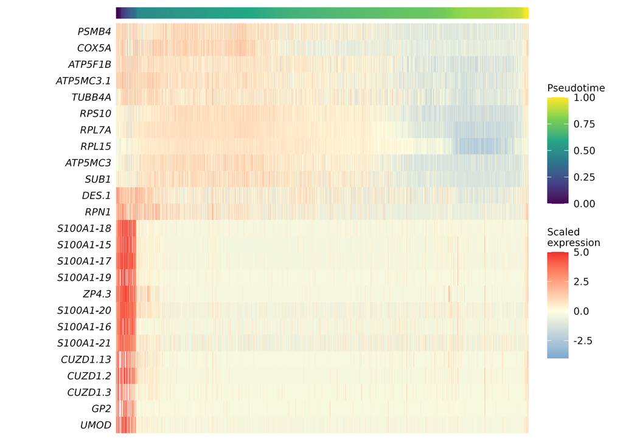

### Path 15.2, up

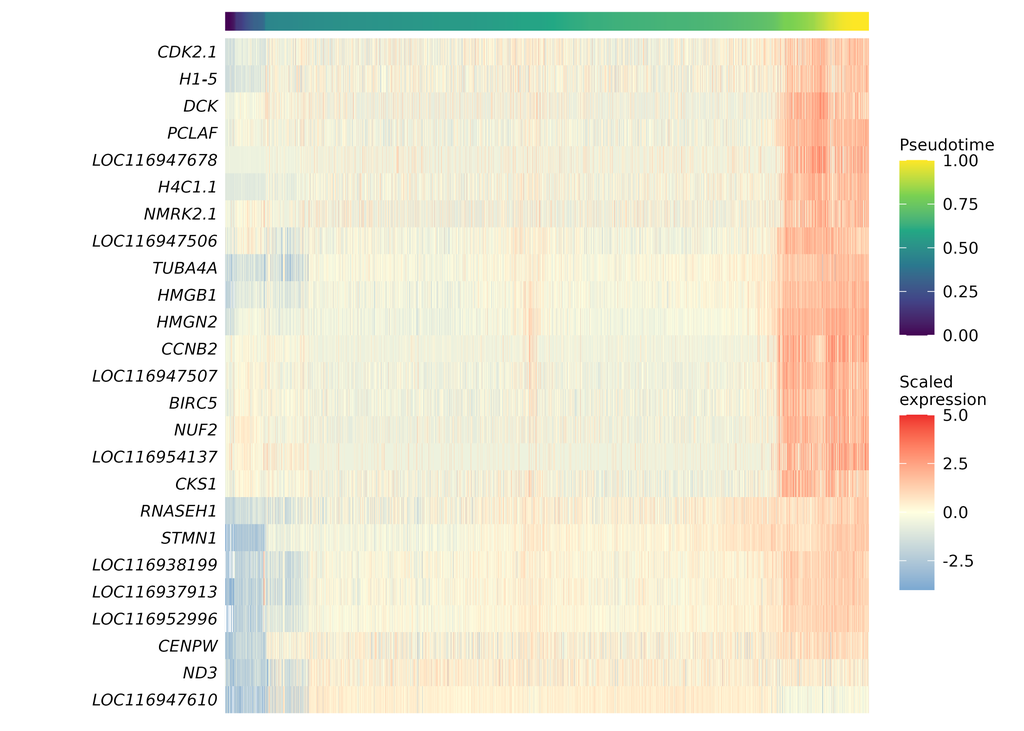

### Path 15.2, down

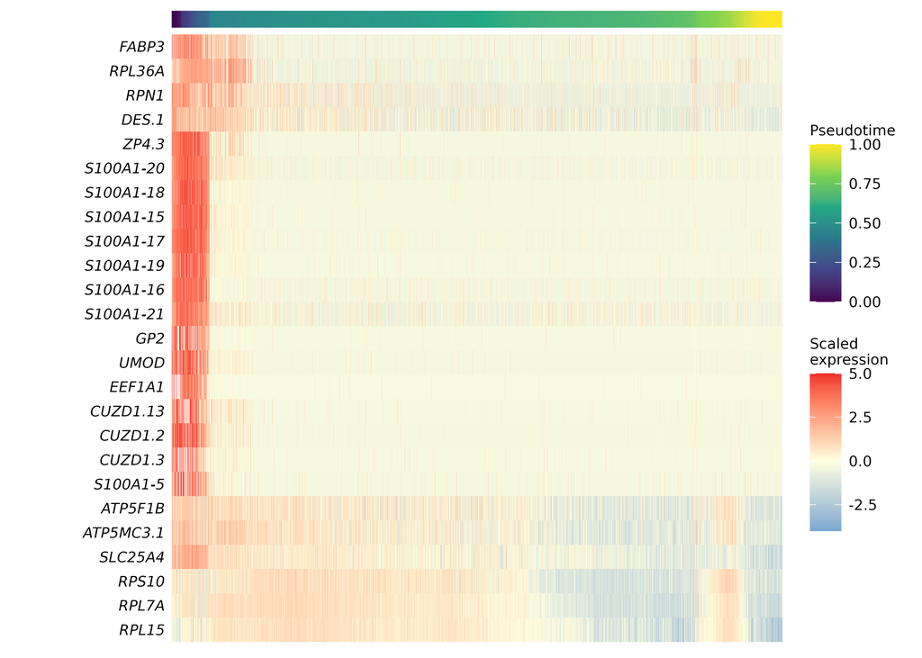

### Path 18.7, up

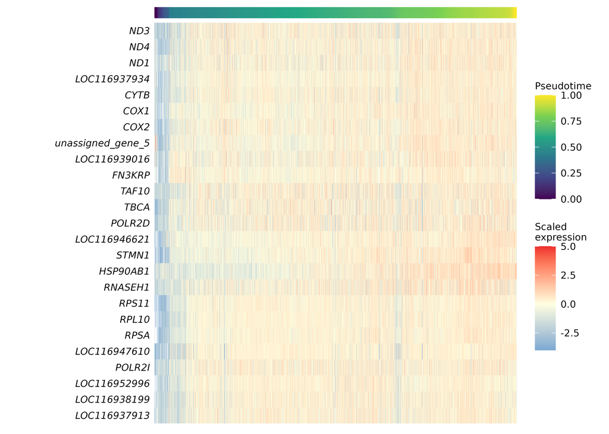

### Path 18.7, down

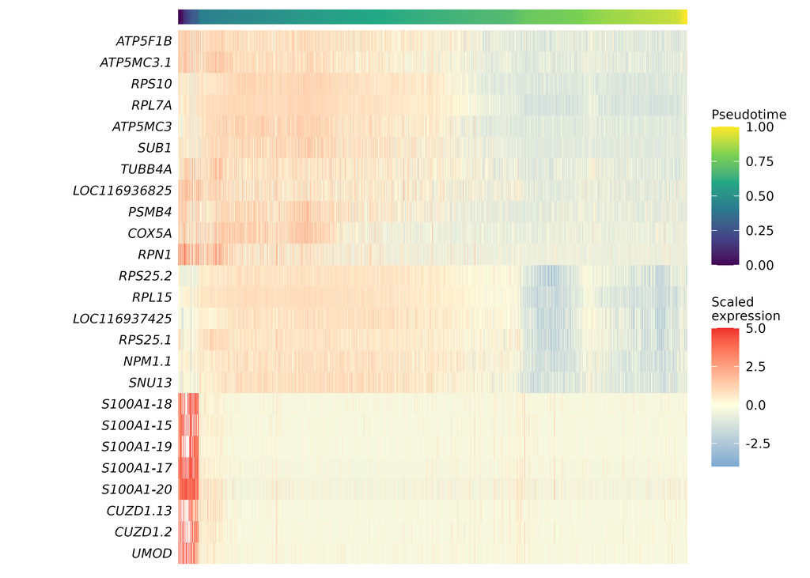

## GO enrichment of pseudotime-associated genes

GO enrichment for each path and direction, against every gene in the data. Terms with p < 0.05 are shown and written to `pseudotime_GO_pvalues.csv`.

```r
path_go = run_go_enrichment(
  gaf              = gaf,
  gene_description = gene_description,
  go_names         = go_names,
  test_genes       = pt_tab %>%
                       dplyr::transmute(Gene, set = paste0(Path, ".", Direction)) %>%
                       dplyr::distinct(),
  background_n     = nrow(combined),
  group2_label     = "Path",
  ngroup2_label    = "nPathGenes",
  overlaps_file    = paste0(results_dir, "/pseudotime_GO_overlaps.csv"),
  pvals_file       = paste0(results_dir, "/pseudotime_GO_pvalues.csv"),
  pval_filter      = params$go_pval)

datatable(path_go %>% dplyr::mutate(dplyr::across(where(is.numeric),
                                                  ~signif(., 3))),
          filter = "top", rownames = FALSE)
```

| GOID | GOName | nGOTermGenes | Path | nPathGenes | nSharedGenes | Pval | FDR |
| --- | --- | --- | --- | --- | --- | --- | --- |
| GO:0000027 | ribosomal large subunit assembly | 16 | 15.4.up | 2100 | 5 | 0.0142 | 0.124 |
| GO:0000027 | ribosomal large subunit assembly | 16 | 16.1.up | 1670 | 6 | 0.000782 | 0.018 |
| GO:0000027 | ribosomal large subunit assembly | 16 | 16.7.up | 3430 | 6 | 0.0283 | 0.188 |
| GO:0000027 | ribosomal large subunit assembly | 16 | 17.1.up | 1510 | 9 | 2.42e-07 | 1.81e-05 |
| GO:0000027 | ribosomal large subunit assembly | 16 | 5.4.down | 7810 | 10 | 0.0256 | 0.139 |
| GO:0000027 | ribosomal large subunit assembly | 16 | 5.9.down | 2910 | 8 | 0.000451 | 0.00413 |
| GO:0000028 | ribosomal small subunit assembly | 15 | 15.2.up | 2220 | 11 | 1.03e-08 | 6.72e-07 |
| GO:0000028 | ribosomal small subunit assembly | 15 | 15.4.up | 2100 | 12 | 1.97e-10 | 2.09e-08 |
| GO:0000028 | ribosomal small subunit assembly | 15 | 16.1.up | 1670 | 13 | 2.43e-13 | 3.43e-11 |
| GO:0000028 | ribosomal small subunit assembly | 15 | 16.7.up | 3430 | 11 | 9.85e-07 | 0.000105 |

[output cut: 1236 more lines]

# Export

```r
out = data.frame(barcode    = colnames(merged),
                 node       = as.character(merged$node),
                 cluster    = as.character(merged$final_label),
                 annotation = as.character(merged$annotation),
                 library    = as.character(merged$library),
                 stage      = as.character(merged$stage),
                 pseudotime = merged$pseudotime,
                 stringsAsFactors = FALSE)

write.csv(out, file = paste0(results_dir, "/pseudotime_per_cell.csv"),
          row.names = FALSE)
```

## Everything written by this document

Built by listing the results directory and looking each file up, rather than by keeping a list by hand. A file with no description, or a description with no file, is reported below instead of passing unnoticed.

```r
file_notes = c(
  "pseudotime_per_cell.csv" = "One row per cell: node, cluster, annotation carried by barcode, library, stage and pseudotime.",
  "cluster_by_annotation.csv" = "How the annotation is distributed across the atlas clusters, before subclustering.",
  "node_composition.csv"      = "Cells per node and the cluster each node came from.",
  "node_by_annotation.csv"    = "Annotation composition of every node, as counts and fractions. The evidence behind panel B of the node graph.",
  "node_marker_set_scores.csv" = "Each node scored on the germ cell marker sets. The root rule is applied to this table.",
  "node_graph_layout.csv"        = "Where each node sits on the node graph figure, so the same tree can be drawn elsewhere.",
  "mst_edges.csv"             = "Every edge of the tree with four reads on it: its length in the corrected space, where each node ranks in the other's neighbor list, the centroid distance in standard deviations of the within-node spread, its length as a percentage of the outgroup threshold, and the percentage of subsampled trees containing it.",
  "annotation_pseudotime.csv" = "Median and quartiles of pseudotime for each annotation. The ordering claim in numbers.",
  "pseudotime_vs_technical.csv"   = "Pseudotime regressed on depth, mitochondrial, rRNA and ribosomal content, pooled and within each library.",
  "node_depth_and_technical.csv" = "Depth, genes detected, percent mitochondrial, rRNA and ribosomal per node.",
  "node_depth_tests.csv"      = "Kruskal-Wallis of each measure across the subclusters of a cluster, with the fold range in median depth.",
  "node_marker_expression.csv" = "The per-gene values behind the node identity bubble plot.",
  "node_marker_genes.csv"     = "Markers of each node against the other nodes of this lineage.",
  "node_marker_GO_overlaps.csv" = "Which marker genes carry each enriched GO term, per node.",
  "node_marker_GO_pvalues.csv" = "GO enrichment of each node's marker genes.",
  "pseudotime_GO_overlaps.csv" = "Which genes carry each enriched GO term, per path and direction.",
  "pseudotime_GO_pvalues.csv" = "GO enrichment of the pseudotime-associated genes, per path and direction.",
  "pseudotime_genes.csv"      = "Genes whose expression changes along each path, one row per gene per path with its direction.",
  "trajectory_umap.png"       = "UMAP colored by annotation and by pseudotime, with the tree drawn over it.",
  "node_graph.png"            = "The tree laid out by its own structure: nodes sized by cell count, colored by mean pseudotime and by most common annotation.",
  "node_graph.pdf"            = "The node graph as a vector file, for figure assembly.",
  "node_by_annotation.png"    = "Annotation composition of each node as stacked bars.",
  "pseudotime_by_annotation.png" = "Pseudotime distribution per annotation and per library.",
  "pseudotime_variance_by_library.png" = "Pseudotime within each library, and the share of its variance that sits between libraries rather than within them.",
  "pseudotime_variance_by_library.csv" = "That share split into stage, what separating the libraries adds over stage, and the remainder within libraries.",
  "node_identity_scores.csv"  = "Each node against all marker sets, somatic ones included, with a contained_in flag where one set sits inside another.",
  "pseudotime_by_node.png"    = "Pseudotime distribution per node and per library.",
  "node_depth_and_technical.png" = "Depth and technical content per node.",
  "removal_evidence_bubble.png" = "The sets named by removal_evidence_sets, per node, with any node being removed first on the axis. The evidence behind a removal.",
  "node_identity_scores.png"  = "Marker expression per node, one dot per gene, every set.",
  "node_graph_ranks.png" = "The tree with two arrows per pair, each colored by how the node it points to ranks among the neighbors of the node it leaves.",
  "node_graph_ranks.pdf" = "The rank graph as a vector file.",
  "node_graph_marker_sets.png" = "The tree once per germ marker set, colored by expression relative to that set's maximum and sized by percent of cells detecting it.",
  "node_graph_marker_sets.pdf" = "The marker set panels as a vector file.")

in_dir  = sort(setdiff(list.files(results_dir), "Robjects"))
in_dir  = in_dir[!grepl("^pseudotime_heatmap_", in_dir)]

# The table describes what this document writes. The results directory also
# holds whatever earlier runs left behind, and those are named below rather
# than given rows with no description.
on_disk = intersect(names(file_notes), in_dir)
unknown = setdiff(in_dir, names(file_notes))
missing = setdiff(names(file_notes), in_dir)

export_tab = data.frame(
  file = on_disk,
  size = sapply(file.path(results_dir, on_disk),
                function(f) format(structure(file.size(f), class = "object_size"),
                                   units = "auto")),
  what = unname(file_notes[on_disk]),
  stringsAsFactors = FALSE)

datatable(export_tab, rownames = FALSE, escape = FALSE,
          options = list(pageLength = 30, dom = "tp",
                         columnDefs = list(list(width = "240px", targets = 0))))
```

| file | size | what |
| --- | --- | --- |
| pseudotime_per_cell.csv | 1.7 Mb | One row per cell: node, cluster, annotation carried by barcode, library, stage and pseudotime. |
| cluster_by_annotation.csv | 446 bytes | How the annotation is distributed across the atlas clusters, before subclustering. |
| node_composition.csv | 634 bytes | Cells per node and the cluster each node came from. |
| node_by_annotation.csv | 2.8 Kb | Annotation composition of every node, as counts and fractions. The evidence behind panel B of the node graph. |
| node_marker_set_scores.csv | 2.7 Kb | Each node scored on the germ cell marker sets. The root rule is applied to this table. |
| node_graph_layout.csv | 1.6 Kb | Where each node sits on the node graph figure, so the same tree can be drawn elsewhere. |
| mst_edges.csv | 1.4 Kb | Every edge of the tree with four reads on it: its length in the corrected space, where each node ranks in the other's neighbor list, the centroid distance in standard deviations of the within-node spr… |
| annotation_pseudotime.csv | 566 bytes | Median and quartiles of pseudotime for each annotation. The ordering claim in numbers. |
| pseudotime_vs_technical.csv | 1.3 Kb | Pseudotime regressed on depth, mitochondrial, rRNA and ribosomal content, pooled and within each library. |
| node_depth_and_technical.csv | 1.4 Kb | Depth, genes detected, percent mitochondrial, rRNA and ribosomal per node. |

[output cut: 24 more lines]

3 file(s) in the directory are not written by this document and are left out of the table: figure6_node_by_library.csv, figure6.pdf, figure6.png. Either an earlier version wrote them, or they are new and need a line in file_notes.

Written to /mnt/ufs18/rs-013/bioinformaticsCore/projects/chong_davidson/BCC125_sea_lamprey_scRNA/results/20260813_pseudotime_fine_all_all_IEG_remove_fig6. Cached intermediates are in Robjects and are not listed.

# Summary

```r
summary_tbl = data.frame(
  quantity = c("lineage", "clusters", "cells", "libraries kept", "nodes",
               "sub_k", "minimum node size", "root", "paths",
               paste0("gene-path results at FDR < ", params$fdr_cut)),
  value = c(lineage,
            paste(clusters, collapse = ", "),
            format(ncol(merged), big.mark = ","),
            paste(objs$kept_batches, collapse = ", "),
            as.character(nlevels(merged$node)),
            as.character(params$sub_k),
            as.character(params$min_node_cells),
            root,
            as.character(n_paths),
            if (have_pt) format(nrow(pt_tab), big.mark = ",") else "not tested"),
  stringsAsFactors = FALSE)

datatable(summary_tbl, rownames = FALSE, colnames = c("", ""),
          options = list(dom = "t", ordering = FALSE, paging = FALSE))
```

| lineage | all |
| --- | --- |
| clusters | 5, 15, 16, 17, 18 |
| cells | 17,057 |
| libraries kept | TF_C00004337, TM_C00004374, UND1_C00004336, UND2_C00004362 |
| nodes | 38 |
| sub_k | 10 |
| minimum node size | 30 |
| root | 5.7 |
| paths | 8 |
| gene-path results at FDR &lt; 0.01 | 77,466 |

# Parameters

Every setting this document was given, with the ones the knit script changed marked. These are the values the run used, so they describe the numbers on this page rather than the defaults in the source.

```r
datatable(params_table(params), rownames = FALSE,
          colnames = c("parameter", "value", "where it came from"),
          options = list(dom = "t", ordering = FALSE, paging = FALSE))
```

| parameter | value | where it came from |
| --- | --- | --- |
| all_clusters | 5,15,16,17,18 |  |
| atlas_suffix |  |  |
| dist_method | simple |  |
| drop_nodes | 5.1 |  |
| edge_boot | 100 |  |
| edge_boot_cells | 100 |  |
| extra_marker_file | neural_crest_markers_2026-09-25.csv,immediate_early_markers_2026-10-06.csv |  |
| fdr_cut | 0.01 |  |
| female_clusters | 5 |  |
| genome_dir | /mnt/research/bioinformaticsCore/shared/Genomes/Petromyzon_marinus |  |

[output cut: 22 more lines]